**LITERATURE REVIEW**

**J Neurosurg Spine** 32:106–126, 2020

E

ach year, approximately 400,000 Americans un-

dergo a spinal fusion operation for the treatment of

neck or back pain, radiculopathy, and/or myelopa-

thy.<sup>77</sup> These operations account for the highest aggregate

hospital cost of any surgical procedure in America, esti-

mated at $13 billion in 2011.<sup>89</sup> Consequently, demonstra-

tion of clinical efficacy is paramount given increasing

scrutiny of cost-effective care. Prior studies have suggested

that clinical improvement following spinal fusion surgery

is often in accordance with the radiological success of fu-

sion, as defined by continuous bony union across the fu-

sion site.<sup>3,59,87</sup> For this reason, emphasis has been placed on

reducing the rates of nonunion, or pseudarthrosis, which

are reported to be as high as 81% in some small series.<sup>9,20,</sup>

29, 32 ,64,82 Interventions to accomplish this goal include pre-

operatively addressing risk factors (e.g., diabetes, chronic

steroid use, and cigarette use)<sup>51</sup> and improving operative

technique (e.g., adequate decortication, removal of inter-

posing soft tissues, and sufficient bone graft).<sup>12</sup> Addition-

ally, new technologies are continuously being investigated

to enhance the fusion rate, including the use of recombi-

nant human growth factors (e.g., bone morphogenetic pro-

**ABBREVIATIONS** CCS = capacitive coupling stimulation; DCS = direct current stimulation; ICS = inductive coupling stimulation; PEMF = pulsed electromagnetic field.

**SUBMITTED** April 18, 2019. **ACCEPTED** May 17, 2019.

**INCLUDE WHEN CITING** Published online October 8, 2019; DOI: 10.3171/2019.5.SPINE19465.

**The effect of electrical stimulation therapies on spinal**

**fusion: a cross-disciplinary systematic review and**

**meta-analysis of the preclinical and clinical data**

**Ethan Cottrill, MS, Zach Pennington, BS, A. Karim Ahmed, BS, Daniel Lubelski, MD,**

**Matthew L. Goodwin, MD, PhD, Alexander Perdomo-Pantoja, MD, Erick M. Westbroek, MD,**

**Nicholas Theodore, MD, Timothy Witham, MD, and Daniel Sciubba, MD**

Department of Neurosurgery, The Johns Hopkins School of Medicine, Baltimore, Maryland

**OBJECTIVE** Nonunion is a common complication of spinal fusion surgeries. Electrical stimulation technologies

(ESTs)—namely, direct current stimulation (DCS), capacitive coupling stimulation (CCS), and inductive coupling stimula-

tion (ICS)—have been suggested to improve fusion rates. However, the evidence to support their use is based solely on

small trials. Here, the authors report the results of meta-analyses of the preclinical and clinical data from the literature to

provide estimates of the overall effect of these therapies at large and in subgroups.

**METHODS** A systematic review of the English-language literature was performed using PubMed, Embase, and Web of

Science databases. The query of these databases was designed to include all preclinical and clinical studies examining

ESTs for spinal fusion. The primary endpoint was the fusion rate at the last follow-up. Meta-analyses were performed

using a Freeman-Tukey double arcsine transformation followed by random-effects modeling.

**RESULTS** A total of 33 articles (17 preclinical, 16 clinical) were identified, of which 11 preclinical studies (257 animals)

and 13 clinical studies (2144 patients) were included in the meta-analysis. Among preclinical studies, the mean fusion

rates were higher among EST-treated animals (OR 4.79, p < 0.001). Clinical studies similarly showed ESTs to increase

fusion rates (OR 2.26, p < 0.001). Of EST modalities, only DCS improved fusion rates in both preclinical (OR 5.64, p

< 0.001) and clinical (OR 2.13, p = 0.03) populations; ICS improved fusion in clinical studies only (OR 2.45, p = 0.014).

CCS was not effective at increasing fusion, although only one clinical study was identified. A subanalysis of the clinical

studies found that ESTs increased fusion rates in the following populations: patients with difficult-to-fuse spines, those

who smoke, and those who underwent multilevel fusions.

**CONCLUSIONS** The authors found that electrical stimulation devices may produce clinically significant increases in

arthrodesis rates among patients undergoing spinal fusion. They also found that the pro-arthrodesis effects seen in

preclinical studies are also found in clinical populations, suggesting that findings in animal studies are translatable. Ad-

ditional research is needed to analyze the cost-effectiveness of these devices.

https://thejns.org/doi/abs/10.3171/2019.5.SPINE19465

**KEYWORDS** spinal fusion; electrical stimulation; pseudarthrosis; nonunion; surgical technique

**J Neurosurg Spine** Volume 32 • January 2020

**106**

©AANS 2020, except where prohibited by US copyright law

**J Neurosurg Spine** Volume 32 • January 2020

**107**

**Cottrill et al.**

tein–2),<sup>27,43,76</sup> mesenchymal stem cells,<sup>79</sup> novel bone graft

substitutes,<sup>31,73</sup> and dynamic instrumentation.<sup>65,91</sup> Postop-

erative electrical stimulation therapy has also been sug-

gested as an attractive adjuvant therapy to enhance or ac-

celerate bony union.<sup>4,49</sup>

The use of electrical stimulation therapy to induce fu-

sion has been investigated clinically since at least 1812,

when Birch successfully treated a patient with tibial non-

union using “[s]hocks of electric fluid . . . passed [daily]

through the space between the ends of the bones both in

direction of the length of the limb and that of its thick-

ness.”<sup>50</sup> A considerable body of evidence has since been

generated to support the general concept that electrical

energy influences living bone (as well as other biologi-

cal tissues).<sup>6</sup> Notably, in the 1950s, Fukada and Yasuda

described the piezoelectric effect of bone, defined as the

generation of electric potentials in bone subjected to me-

chanical stresses. Using a custom galvanometer, they doc-

umented an electrical potential across the stressed bone,

with the compressed bone being electronegative and the

side under tension being electropositive.<sup>44</sup> Subsequently,

Friedenberg and Brighton described the bioelectric po-

tentials in bone, in which areas of bone undergoing ac-

tive repair or growth are electronegative relative to areas

at rest.<sup>40,41</sup> Therapeutic electrical stimulation devices are

based on these biophysical principles—namely, that the

external application of an electrical stimulus can stimu-

late bone growth through the induction of a negative bio-

electric potential.

There are currently 3 types of electrical stimulation

therapies used in spinal fusion: direct current stimulation

(DCS), capacitive coupling stimulation (CCS), and induc-

tive coupling stimulation (ICS), also known as pulsed

electromagnetic field (PEMF) therapy (Fig. 1). Conven-

tionally, DCS involves the implantation of cathodes (nega-

tive electrodes) into the prospective fusion mass and an

delivered to the fusion site via a subcutaneously implanted

electric generator; the lifetime of this current is dictated

by the charge size of the implanted battery, although most

devices operate for a minimum of 6 months.<sup>16,39,42</sup> CCS,

in contrast to DCS, is completely noninvasive and em-

ploys two capacitive plates placed on the skin on opposite

sides of the fusion site. Alternating current is applied to

the plates, setting up an oscillating electric field (1–100

mV/cm). As the battery pack is external, it may be replaced

and recharged, allowing for continuous use (24 hours/day)

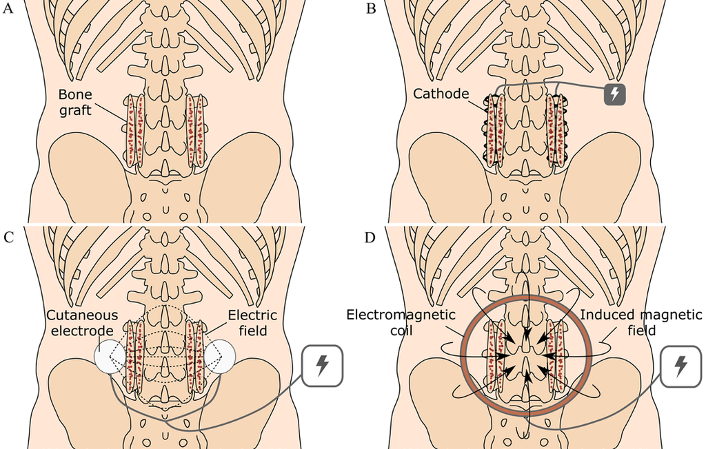

**FIG. 1.** Conceptual illustrations of the 3 types of electrical stimulation therapies used in spinal fusion. **A:** Posterolateral L3–5

inter–transverse process spinal fusion using bone graft, without electrical stimulation. **B–D:** Same procedure illustrating postoper-

ative adjuvant therapy with DCS (B), CCS (C), or ICS (D), sometimes referred to as PEMF. In B, the electric generator is typically

implanted subcutaneously. In C and D, the electric generators are externally located. Copyright Ethan Cottrill. Published with

permission. Figure is available in color online only.

**Cottrill et al.**

**J Neurosurg Spine** Volume 32 • January 2020

**108**

until there is radiological confirmation of fusion. Lastly,

ICS employs electromagnetic coils placed over the fusion

site. Alternating current applied to these coils induces an

electromagnetic field covering the fusion site.<sup>83</sup> Compared

to CCS, ICS devices require shorter daily usage, with only

30 minutes to 2 hours of continuous use required per day

until radiological confirmation of fusion is established.

The mechanisms of action and the relative technical ad-

vantages and disadvantages of these 3 therapies are sum-

marized in Table 1.<sup>1,7,8,10,11,16,17,19,21,23,30,37,66,85,88,92,93</sup>

Although prior reviews have described the effects of

electrical stimulation therapies on spinal fusion, none to

date have systematically evaluated both the preclinical and

clinical literature of all 3 available technologies. In this ar-

ticle, we perform such a review as a means of compiling

the current evidence and validating the translatability of

results achieved using these technologies in animal mod-

els. We set out to evaluate the available English-language

literature for all 3 technologies, asking of each one: 1) To

what degree does the technology improve bony fusion in

animal models? 2) To what degree does the technology

facilitate bony fusion in humans? Additionally, we report

the results of a meta-analysis of the available clinical stud-

ies to provide an estimate of the overall effect at large and

in subgroups.

**Methods**

**Electronic Literature Search**

A systematic review of the literature was performed us-

ing PubMed, Embase, and Web of Science databases. The

search query was designed to obtain all of the available in

vivo data (preclinical and clinical) examining the effect

of electrical stimulation therapies on spinal fusion. The

query for the PubMed database was as follows: (spinal

fusion[mesh] OR spine fusion*[tw] OR spinal fusion*[tw]

or spinal arthrodes*[tw] OR cervical fusion*[tw] OR lum-

bar fusion*[tw] OR lumbosacral fusion*[tw] OR interbody

fusion*[tw] OR posterolateral fusion*[tw] OR cervical

arthrodes*[tw] OR lumbar arthrodes*[tw] OR lumbosacral

arthrodes*[tw] OR interbody arthrodes*[tw] OR postero-

lateral arthrodes*[tw]) AND (electric stimulation[mesh]

OR electric stimulation therapy[mesh] OR electromag-

netic fields[mesh] OR “electrical stimulation”[tw] OR

“pulsed electromagnetic field*”[tw] OR “electromagnetic

pulsing*”[tw] OR “magnetic fields*”[tw] OR “direct cur-

rent stimulation*”[tw] OR “bone growth stimulation*”[tw]

OR “electrical current*”[tw] OR “capacitively coupl*”[tw]

OR “capacitive coupl*”[tw] OR “capacitive stimulat*”[tw]

OR “inductively coupl*”[tw] OR “inductive coupl*”[tw]

OR “inductive stimulat*”[tw]). This query was stylisti-

cally modified for use in the Embase and Web of Science

databases. The bibliographies of the included studies were

also queried for additional sources.

Included studies were preclinical or clinical peer-re-

viewed publications with full English-language text avail-

ability that evaluated the effects of one or more electrical

stimulation therapies on spinal fusion. We defined electri-

cal stimulation as the therapeutic use of electromagnetic

energy (including direct current, capacitive coupling, and

inductive coupling) with the expressed intent of promot-

ing bony fusion after instrumented or noninstrumented

spinal fusion. Studies were excluded if they examined a

surgical model other than spinal fusion or if they mixed

the results of spinal fusion with other surgical models.

Eligible studies were screened against these criteria by

two reviewers (E.C. and Z.P.); a third reviewer (A.K.A.)

served as a referee, resolving any discrepancies between

the first two reviewers. Critical Appraisal Checklists ob-

tained from the Joanna Briggs Institute at The University

of Adelaide were used to assess the quality of the clinical

studies included in the meta-analysis.<sup>71</sup> Because preclini-

cal studies are all classified as level of evidence V, a simi-

lar appraisal was not conducted for them. Additionally,

the QUOROM (Quality of Reporting of Meta-analyses)

checklist was used for this systematic review and meta-

analysis.<sup>70</sup>

**Data Extraction**

Studies meeting the inclusion criteria were reviewed

to extract details regarding the type of electrical stimula-

tion, specifications of the electrical therapy, means of de-

termining bony fusion, and the overall fusion rate at last

follow-up. For preclinical studies, we also recorded details

about the animal species and surgical model employed.

For clinical studies, we included details on the patient de-

mographics and the surgical approach.

For both preclinical and clinical studies, the primary

endpoint was the fusion rate at last follow-up. In preclini-

cal studies, we defined this as the total number of levels

fused divided by the total number of levels included in the

prospective fusion mass. In clinical studies, we defined the

fusion rate as that derived from the proportion of patients

experiencing a successful radiological fusion at the last

follow-up visit. The definition and method of assessment

of fusion were recorded for each study.

**Statistical Analysis**

Statistical meta-analyses were performed using R ver-

sion 3.4.2 (The R Foundation for Statistical Computing).

Separately for the preclinical and clinical studies, we gen-

erated mean fusion rates and odds ratios using the Free-

man-Tukey double arcsine transformation, a previously

established method for normalizing proportions with vari-

ance stabilization.<sup>38</sup> A random-effects meta-analysis was

then employed to give a pooled estimate of the effect of

electrical stimulation on fusion rates. We elected to forego

a numbers-needed-to-treat analysis based on these results,

as prior reports have demonstrated such estimates to be

commonly misleading.<sup>81</sup> Using this methodology, we also

performed subgroup analyses of the clinical data based on

smoking status, surgical history (index vs revision proce-

dure), use of interbody devices, region fused, type of bone

graft, use of instrumentation, and number of levels fused.

For all analyses, an a of 0.05 was used as the definition of

statistical significance.

**Results**

Our search identified 340 unique articles, and 47 of

these met our inclusion criteria (Fig. 2). After reviewing

the full texts, we included 17 preclinical studies<sup>15,22, 25, 28,</sup>

**J Neurosurg Spine** Volume 32 • January 2020

**109**

**Cottrill et al.**

**TABLE 1. Mechanisms of action and relative technical advantages and disadvantages of the 3 types of electrical stimulation therapies used in spinal fusion surgery**

Electrical Stimulation

Therapy

Mechanisms of Action

Relative Technical Advantages

Relative Technical Disadvantages

DCS

1) Electrochemical (faradic) reaction at the cathode lowers

the oxygen tension & raises the pH, favoring net bone

formation:7,11,16 *2 H**2**O* + *4 e**−* + *O**2* *= 4 OH**−*. 2) Generation

of H2O2 at the cathode stimulates macrophage secretion

of vascular endothelial growth factor, a potent angio-

genic agent involved in bone healing.21 3) Upregulation

of osteoinductive growth factors (e.g., BMP-2, 6, & 7).37

1) Continuous, focal delivery of direct

electric current for the life of the battery/

device. 2) Virtually 100% pt compliance

(requires no further action from the pt

following implantation).

1) Risks associated w/ the surgical implantation of a medical device

(e.g., infection, immune reaction, protrusion causing discomfort,

device breakage or malfunction, release of toxic substances).

2) May require additional training by the surgeon for correct

implantation. 3) May require an additional surgery for remov-

ing the electrical generator following successful fusion. 4) May

be incompatible w/ MRI (contrast w/ CCS & ICS, which involve

external, removable devices).

CCS

1) Direct activation of osteoblastic membrane-bound

voltage-gated Ca channels leads to an increase in

cytosolic Ca2+, inducing downstream phospholipase-

A2− & calmodulin-mediated bone formation.8,17,23,30,92

2) Upregulation of osteoinductive growth factors (e.g.,

BMP-2, 4, 5, 6, & 7; & TGF-β1).88,93

1) Noninvasive & theoretically painless. 2)

Relatively lightweight & discreet; wear-

able 24 hrs/day.

1) Requires active pt participation, w/ recommended usage of 24

hrs/day throughout the duration of therapy. 2) Possible device-

related medical complications, including electric shock, burns, &

immune reaction to the cutaneous electrodes (& undetermined

carcinogenicity & mutagenicity).

ICS

1) Direct release of Ca2+ from intracellular stores, inducing

downstream calmodulin-mediated bone formation.17,23,92

2) Modulation of osteoblastic PTH signaling at the

plasma membrane, reducing inhibitory effects on col-

lagen synthesis.19,66 3) Upregulation of osteoinductive

growth factors (e.g., BMP-2 & 4; TGF-β1; & FGF-2).1,10,85

1) Noninvasive & theoretically painless. 2)

Recommended usage is 30 mins to 2 hrs

per day (compare to CCS).

1) Requires active pt participation throughout the duration of thera-

py. 2) Heavier & more obtrusive than CCS devices.

BMP = bone morphogenetic protein; Ca = calcium; FGF = fibroblast growth factor; pt = patient; PTH = parathyroid hormone; TGF = transforming growth factor.

**Cottrill et al.**

**J Neurosurg Spine** Volume 32 • January 2020

**110**

35–37, 46, 48, 52, 54–56, 67, 75, 86,94 and 16 clinical studies.5,14, 26, 34, 47, 53, 57,

60, 63, 68, 69, 72, 74, 78, 84,90 Among the 14 excluded articles, the rea-

sons for exclusion were lack of full-text availability (n =

10), surgical model other than spinal fusion (n = 2), and

lack of an English-language translation (n = 2). Of these

33 articles, 11 preclinical (257 animals; 273 levels) and 13

clinical (2144 patients) studies were ultimately included

in the meta-analysis. The clinical studies were deemed to

have sufficient quality to be included in the meta-analysis

(Critical Appraisal Checklists). The included articles are

summarized in Tables 2 and 3, as well as in Supplemental

Tables 1 and 2. Supplemental Fig. 1 plots these studies by

year of publication, illustrating the dearth of recent studies.

**Overall Effect of Electrical Stimulation Technologies on**

**Spinal Fusion**

In the preclinical literature, the mean fusion rates were

higher among animals treated with electrical stimulation

therapy (77.7%) than among controls (42.0%). Across all

studies, the use of electrical stimulation produced a nearly

fivefold increase in the odds of a successful fusion (OR

4.79 [95% CI 2.51–9.16], p < 0.001) (Table 4). In the clini-

cal literature, electrical stimulation similarly was shown

to produce higher rates of fusion versus controls in which

no electrical stimulation therapy was administered (84.9%

vs 73.4%, respectively), although the overall effect was

smaller than in the preclinical literature (OR 2.26 [95% CI

1.48–3.44], p < 0.001) (Table 4). Figure 3A illustrates the

random-effects meta-analysis of the fusion rates from all

clinical studies.

**Effect of DCS on Spinal Fusion**

Eleven preclinical and 9 clinical studies investigating

the effect of DCS on spinal fusion were identified, and

8 preclinical and 6 clinical studies were included in the

meta-analysis.

Preclinical Data

The preclinical studies (Table 2) involved rat (n = 1),

rabbit (n = 4), dog (n = 2), pig (n = 1), sheep (n = 1), goat (n

= 1), and monkey (n = 1) spinal fusion models. All surgi-

cal models involved one-level fusions of the lumbar spine,

with 3 using posterior facet joint fusion, 5 using postero-

lateral inter–transverse process fusion, and 3 using inter-

body fusion. Among these studies, 11 used autograft, 1

used allograft, and 1 used synthetic bone graft; 3 of the

studies employed instrumentation in the fusion construct.

All but one study used implantable electrodes in the fu-

sion beds. The remaining study routed electrical current

through pedicle screws and rods.<sup>67</sup>

The reported fusion rates ranged between 70% and

100% for the treatment group and between 0% and 73%

for controls (Supplemental Fig. 2A). On meta-analysis,

the mean fusion rate was found to be significantly higher

in DCS-treated levels than in controls (OR 5.64 [95% CI

2.64–12.06], p < 0.001) (Table 4).

Clinical Data

Nine clinical studies examined the effects of DCS on

spinal fusion: 8 studies in adult cohorts and 1 study in a

pediatric cohort (Table 3). Four studies examined its use

in patients with difficult-to-fuse spines using the follow-

ing definitions: 1) age > 60 years;<sup>5</sup> 2) multiple prior spine

surgeries, failed prior fusion, segmental instability, spinal

stenosis, and/or spondylolisthesis;<sup>60</sup> 3) multilevel fusion,

failed prior fusion, and/or grade II or worse spondylolis-

thesis;<sup>84</sup> and 4) age > 65 years, presence of rheumatoid

arthritis, failed prior fusion, infection, and/or immuno-

suppression.<sup>90</sup> One study was restricted to index proce-

dures, while 8 included both index or revision procedures.

Only 1 study employed interbody fusion; the remaining

8 used solely posterior/posterolateral fusion. The spinal

segments investigated were cervical in 1 study and lum-

bar/lumbosacral in 8. Six studies used autograft only, and

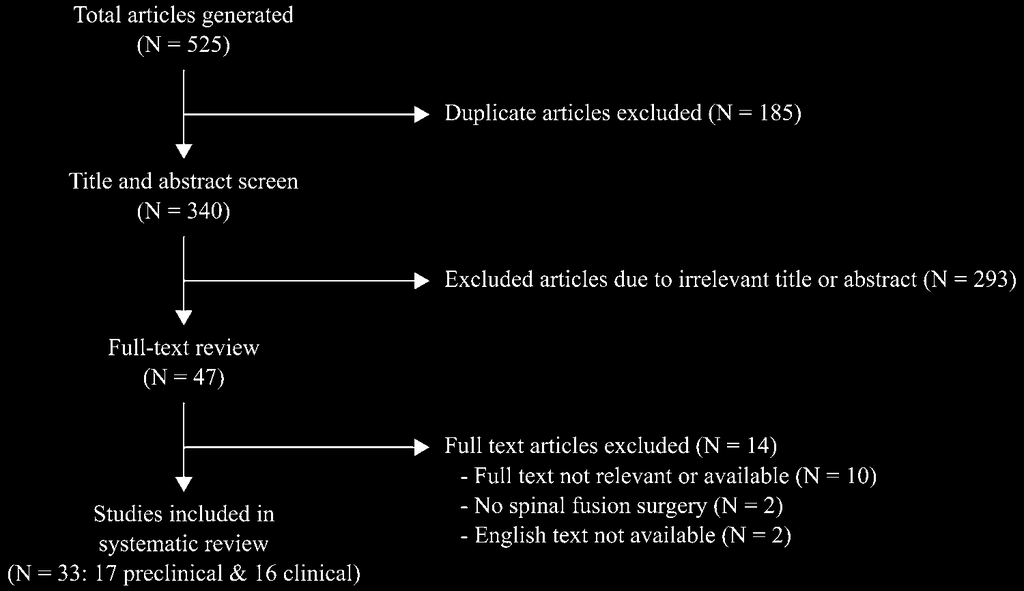

**FIG. 2.** Diagram of the consolidated standards of reporting trials for article selection.

**J Neurosurg Spine** Volume 32 • January 2020

**111**

**Cottrill et al.**

**TABLE 2. Descriptive summaries of the identified preclinical studies (n = 17)**

Authors &

Year (LOE)*

Animal & Surgical

Model

Study Groups

Postop Definition of

Fusion Outcome

Fusion Rate

DCS

Nerubay et al.,

1986 (V)

Pig (n = 20): L5–6 posterior

facet joint fusion w/ iliac

crest autograft

A. DCS via Osteostim model S11; constant 20-μA current (n = 9)

NA

Fusion rate not reported; however, a “signifi-

cant increase of osteoblastic activity with

bone formation” favoring the experimental

group was observed at 2 mos postop (p =

0.037)

B. Control; implantation of the Osteostim device, w/o an active

power source (n = 11)

Kahanovitz &

Arnoczky,

1990 (V)

Dog (n = 4): L1–2 & L4–5

posterior facet joint fusion

w/ local autograft

A. DCS; 10 μA (n = 2; each animal had either L1–2 or L4–5

electrically stimulated)

Histological & radiographic

evidence of complete bony

fusion across the graft &

both facets (defined as 1

level) at 12 wks postop

A. 100% (4/4 levels)

B. Control; implantation of electrodes, w/o an active power source

(n = 2; each animal had L1–2 or L4–5 electrically stimulated)

B. 0% (0/4 levels)

Bozic et al.,

1999 (V)

Rabbit (n = 53): L3–4 poste-

ro lateral inter–transverse

process fusion w/ bone graft

A. Coralline HA w/ autologous bone marrow aspirate & an

implanted DCS device (SpF-100, Electro-Biology, Inc.) (100 μA)

(n = 15)

Blind manual palpation of

fusion segment (graded as

fused or not) at 8 wks

A. 87% (13/15 levels) (significantly higher in

group A than C)

B. Coralline HA w/ autologous bone marrow aspirate & an

implanted DCS device (SpF-XLIIb, Electro-Biology, Inc.) (40

μA) (n = 12)

B. 50% (6/12 levels)

C. Coralline HA w/ autologous bone marrow aspirate (n = 12)

C. 25% (3/12 levels)

Toth et al.,

2000 (V)

Sheep (n = 22): L4–5 discec-

tomy & interbody fusion w/

Ti cage (Bagby & Kuslich) &

iliac crest autograft

Ti interbody cage (Bagby & Kuslich)

filled w/ iliac crest autograft & an

implanted DCS device for 4 mos

A. 100 μA (SpF-100,

Electro-Biology, Inc.) (n

= 8)

Histological evidence of fusion

defined as a continuous

bony bridge from superior to

inferior vertebrae at 4 mos

A. 100% (8/8 levels)

B. 40 μA (SpF-XLII, Electro-

Biology, Inc.) (n = 7)

B. 71% (5/7 levels)

C. Control; 0 μA (n = 7)

C. 29% (2/7 levels); each group statistically

different (Fisher’s exact test, p < 0.009)

Dejardin et al.,

2001 (V)

Dog (n = 5): L1–2 & L4–5

facet joint fusion w/ local

autograft

Postop constant DCS for 12 wks

A. 10 μA/cm (n = 1.5 ani-

mals; 3 levels)

Histological & radiographic

evidence of complete bony

fusion across the graft &

both facets (defined as 1

level) at 12 wks

A. 100% (3/3 levels)

B. 4 μA/cm (n = 2 animals;

4 levels)

B. 100% (4/4 levels)

C. 0.83 μA/cm (n = 1.5

animals; 3 levels)

C. 100% (3/3 levels)

France et al.,

2001 (V)

Rabbit (n = 34): L5–6 pos-

terolateral inter–transverse

process fusion w/ iliac crest

autograft

A. Postop local DCS (60 μA) for 5 wks (n = 12)

NA

Fusion rate not reported; however, via manual

palpation scores & biomechanical testing,

there was no statistically significant differ-

ence btwn the 3 groups

B. Postop local DCS (20 μA) for 5 wks (n = 8)

C. Control; implantation of stimulator but no current (0 μA) (n = 14)

CONTINUED ON PAGE 112 »

**Cottrill et al.**

**J Neurosurg Spine** Volume 32 • January 2020

**112**

**TABLE 2. Descriptive summaries of the identified preclinical studies (n = 17)**

Authors &

Year (LOE)*

Animal & Surgical

Model

Study Groups

Postop Definition of

Fusion Outcome

Fusion Rate

DCS (*cont’d*)

Cook et al.,

2004 (V)

Nonhuman primate (n = 22):

L5–6 anterior lumbar inter-

body fusion w/ iliac crest

autograft & either a femoral

allograft ring or Ti alloy

fusion cage

A. Ti alloy cage w/ autograft & postop local DCS (SpF, Electro-

Biology, Inc.) (19.6 μA/cm2) for 26 wks (n = 4)

CT evidence of fusion defined

as “bridging callus with

trabeculations” at 26 wks

A. 100% (4/4 levels)

B. Ti alloy cage w/ autograft & postop local DCS (SpF, Electro-

Biology, Inc.) (5.4 μA/cm2) for 26 wks (n = 7)

B. 86% (6/7 levels)

C. Ti alloy cage w/ autograft alone (7)

C. 71% (5/7 levels)

D. Femoral ring allograft w/ autograft (n = 4)

D. 75% (3/4 levels) (no statistical significance

btwn groups)

France et al.,

2006 (V)

Rabbit (n = 25) (nicotine &

control models): L5–6 pos-

terolateral inter–transverse

process fusion w/ iliac crest

autograft

A. Postop local DCS (SpF-100, Electro-Biology, Inc.) (100 μA) &

continuous dose of nicotine via transdermal patch (10.5 mg) for

5 wks (n = 9)

Evidence of fusion by manual

palpation, graded 3 separate

times at 5 wks postop; fusion

rate was calculated as the

ratio of fused segments to

total segments tested × 100

A. 85.3% ± 12.7% (approximately 7/9 levels)

(significantly greater than that of group C)

B. Postop continuous dose of nicotine via transdermal patch (10.5

mg) for 5 wks (n = 8)

B. 66.7% ± 7.2% (approximately 5/8 levels)

(significantly greater than that of group C)

C. Control; neither nicotine nor stimulator (n = 8)

C. 37.5% ± 12.5% (approximately 3/8 levels)

Fredericks et

al., 2007

(V)

Rabbit (n = 5): L4–5 postero-

lateral inter–transverse

process fusion w/ iliac crest

autograft

A. Postop local DCS (SpF-100, Electro-Biology, Inc.) (100 μA) for

28 days (n = 2)

Radiographic evidence of bilat

bridging fusion at 4 wks

A. 100% (2/2 levels)

B. Control; no electrical stimulation (n = 3)

B. 33% (1/3 levels)

MacEwan et

al., 2016

(V)

Goat (n = 2): L4–5 interbody

fusion w/ local autograft &

instrumentation permitting

DCS (anodized Ti rods &

pedicle screws)

A. Constant DCS (Varta Microbattery, Inc.) (40 μA) routed directly

through the Ti rods & pedicle screws (novel “osteogenic spinal

instrumentation”) (n = 1)

Micro-CT evidence of fusion,

defined as solid bridging

of the vertebral bodies at

3 mos

A. 100% (1/1 level)

B. Control; same system w/o DCS (n = 1)

B. 0% (0/1 level)

Cho et al.,

2019 (V)

Rat (n = 60); L4–5 postero-

lateral inter–transverse

process fusion w/ tubular

nickel-Ti (nitinol) mesh con-

tainers filled w/ iliac crest

autograft

A. Nitinol container filled w/ autograft & constant DCS (Cyber-

medic, Inc.) (100 μA) for 8 wks (n = 20)

Evidence of fusion by manual

palpation & micro-CT, de-

fined as no intersegmental

motion & continuous bridg-

ing bone at 8 wks

A. 100% (20/20 levels)

B. Nitinol container filled w/ autograft & pulsed DCS (Cybermedic,

Inc.) (100 μA, 100 Hz, 200 μsec) for 8 weeks (n = 20)

B. 100% (20/20 levels)

C. Control: nitinol container filled w/ autograft alone (n = 20)

C. 70% (14/20 levels) (significantly less than A

& B; p < 0.01)

ICS

Kahanovitz et

al., 1984

(V)

Dog (n = 2): L2–4 posterior

lumbar fusion w/ local auto-

graft & instrumentation

A. Postop local ICS (positive pulse: 200 μsec @ 1.1 mV/cm; nega-

tive pulse: 200 μsec @ 9.6 mV/cm; repeated for 5 msec @ 12

Hz); 12 hrs of stimulation/day (n = 1)

NA

Fusion rate not reported; however, radiograph-

ically & histologically “no demonstrable

objective differences” btwn the groups

observed at 15 wks postop

B. Control: no postop ICS (n = 1)

» CONTINUED FROM PAGE 111

CONTINUED ON PAGE 113 »

**J Neurosurg Spine** Volume 32 • January 2020

**113**

**Cottrill et al.**

**TABLE 2. Descriptive summaries of the identified preclinical studies (n = 17)**

Authors &

Year (LOE)*

Animal & Surgical

Model

Study Groups

Postop Definition of

Fusion Outcome

Fusion Rate

ICS (*cont’d*)

Guizzardi et

al., 1994

(V)

Rat (n = 6): L4–6 posterolater-

al inter–transverse process

fusion w/ local autograft

A. Postop ICS (via coils fixed to the outside of the animals’ cages);

mean 2.5 mV for 12 hrs/day (n = 3)

NA

Fusion rate not reported; however, histological

analysis showed an acceleration of bony

callus formation in the experimental group

B. Control; no postop ICS (n = 3)

Kahanovitz et

al., 1994

(V)

Dog (n = 12); L1–2 & L4–5

posterior facet joint fusion

w/ local autograft & wire to

secure the graft in place

Postop local ICS (pulse

burst frequency: 1.5 Hz;

pulse burst duration: 30

msec)

A. 30 mins/day for 12 wks (n = 4)

Histological & radiographic

evidence of complete bony

fusion across graft & both

facets (defined as 1 level) at

12 wks

A. 0% (0/8 levels)

B. 60 mins/day for 12 wks (n = 4)

B. 0% (0/8 levels)

C. Control; no postop ICS (n = 4)

C. 0% (0/8 levels)

Ito et al., 1997

(V)

Dog (n = 26): L5–6 postero-

lateral inter–transverse

process fusion w/ iliac crest

autograft

Postop local ICS (Ameri-

can Medical Electronics,

Inc.) (positive pulse: 195

μsec; negative pulse:

65 μsec; peak change

in positive flux density:

9 T/sec; peak change in

negative flux density: 3

T/sec; pulses/burst: 99;

burst interval: 670 μsec)

A. w/ Steffee (variable screw place-

ment plate) (n = 6)

NA

Fusion rate not reported; however, the authors

noted no statistically significant effect of

pulsed electromagnetic field on the BMD

or biomechanical properties of the fusion

mass at 24 wks postop

B. w/o Steffee plate (n = 7)

Control; no postop local

ICS

C. w/ Steffee plate (n = 6)

D. w/o Steffee plate (n = 7)

Glazer et al.,

1997 (V)

Rabbit (n = 20): L5–6 pos-

terolateral inter–transverse

process fusion w/ iliac crest

autograft

A. Postop external ICS (Orthofix, Inc.) (via coils fixed to the

outside of the animals’ cages); peak change in positive flux

density: 9 T/sec; peak change in negative flux density: 3 T/sec;

pulse burst: 26 msec; burst interval: 670 msec; 4 hrs/day for 6

wks (n = 10)

Radiographic evidence of

bilat fusion, defined as the

presence of a continuous

trabecular pattern across the

fusion mass at 6 wks

A. 80% (8/10 levels)

B. Control; no postop external ICS (n = 10)

B. 60% (6/10 levels) (p > 0.05)

Zhuo et al.,

2018 (V)

Rabbit (n = 32): L5–6 pos-

terolateral inter–transverse

process fusion w/ bone graft

A. Postop ICS (CMF SpinaLogic device, DJO Global; affixed to

the cage) for 30 mins/day for 8 wks & nano-HA–coated bipha-

sic Ca phosphate bone graft substitute (n = 8)

Radiographic evidence of bilat

fusion at 9 wks

A. 100% (8/8 levels)

B. Postop ICS (CMF SpinaLogic device affixed to the cage) for

30 mins/day for 8 wks & biphasic Ca phosphate bone graft

substitute (n = 8)

B. 62.5% (5/8 levels)

C. Nano-HA–coated biphasic Ca phosphate bone graft substitute

alone (n = 8)

C. 75% (6/8 levels)

D. Biphasic Ca phosphate bone graft substitute alone (n = 8)

D. 38% (3/8 levels) (significant improvement w/

nano-HA–coated biphasic Ca phosphate,

p < 0.05)

BMD = bone mineral density; cont’d = continued; HA = hydroxyapatite; LOE = level of evidence; NA = not applicable; Ti = titanium.

* Each preclinical study was classified as level V evidence according to guidelines of the North American Spine Society.

» CONTINUED FROM PAGE 112

**Cottrill et al.**

**J Neurosurg Spine** Volume 32 • January 2020

**114**

**TABLE 3. Descriptive summaries of the identified clinical studies (n = 16)**

Authors & Year, Study

Design (LOE)*

Inclusion Criteria

Surgical Model

Study Groups (no. of pts)

Definition of Fusion Outcome

Fusion Rate (pts)

(p value)

DCS

Nerubay & Katznelson,

1984, case series

(IV)

Pediatric pts w/ spondylolisthesis Posterior lumbar fusion w/

iliac crest autograft w/ or

w/o instrumentation

Osteostim model S11; direct cur-

rent of 20 μA over 4 cathodes (5

μA/cathode); 105-mA/hr battery

capacity for at least 6 mos (n

= 5)

Radiographic evidence of solid bony fusion

at 1 yr

100% (5/5)

Kane, 1988, nonran-

domized, multicenter

(III)

NA

Posterior lumbar fusion w/

autograft

DCS via Osteostim HS1 (BGS

Medical Corp.); 20 μA over 4

cathodes; active for 22 wks (n

= 82)

NA

91.5% (75/82) (p =

0.02)

Historical control: no DCS (n =

159)

80.5% (128/159)

Kane, 1988, prospect

RCT nonblinded (II)

Pts w/ difficult-to-fuse spines:

failed prior fusion, grade II

or worse spondylolisthesis,

multilevel fusion, &/or other

high-risk medical condition

(e.g., gross obesity)

Posterior lumbar fusion (1–4

levels fused) w/ autograft

DCS via Osteostim HS1; 20 μA

over 4 cathodes; active for 22

wks (n = 31)

Radiographic evidence of fusion at 18 mos

81% (25/31) (p =

0.026)

Matched control: no DCS (n = 28)

54% (15/28)

Kane, 1988, nonran-

domized, multicenter

(IV)

NA

Posterior lumbar fusion w/

autograft

DCS via Osteostim HS1; 20 μA

over 4 cathodes; active for 22

wks (n = 116)

Radiographic evidence of fusion (no time

point given)

93% (108/116)

Meril, 1994, retro com-

parative cohort (III)

Adult pts undergoing primary or

revision anterior or posterior

lumbar interbody fusion

Single-level or multilevel

anterior or posterior lumbar

interbody fusion w/ or

w/o instrumentation & w/

autograft &/or allograft

DCS device (EBI Medical Sys-

tems); 20 μA over 2 cathodes;

active for 24 wks (n = 122)

CT evidence of fusion, defined as unequivo-

cal incorporation of the graft into the adja-

cent vertebral endplates on at least half of

the curved coronal views, at ≥21 mos

93% (113/122) (p <

0.001)

Control: no DCS (n = 103)

75% (77/103)

Rogozinski & Rogozin-

ski, 1996, prospect

comparative study

(III)

Adult pts undergoing instrument-

ed lumbosacral PLF

Lumbosacral posterolateral

instrumented fusion w/

autograft (not interbody)

DCS via SpF-2T (EBI Medical Sys-

tems); 20 μA over 2 cathodes w/

220-mA/hr battery (n = 53)

Radiographic evidence of fusion, defined as

mature trabeculated bone across instru-

mented levels w/ no movement on stress

views & no loss of fixation, at ≥19 mos

96% (51/53) (p

>0.05)

Control: no DCS (n = 41)

85% (35/41)

Tejano et al., 1996,

retro case series

(IV)

Pts w/ difficult-to-fuse spines:

multilevel fusion, previous

failed fusion, &/or grade II or

worse spondylolisthesis

Posterior or posterolateral

lumbar fusion w/ iliac crest

autograft w/o instrumenta-

tion

DCS device (EBI Medical Sys-

tems); 20 μA over 4 cathodes

for a minimum of 24 wks (n =

118)

Radiographic evidence of fusion, w/ no mo-

tion btwn vertebrae at ≥2 years

92% (108/118)

Kucharzyk, 1999,

prospect compara-

tive series (II)

Pts w/ difficult-to-fuse spines:

multiple prior spine surgeries,

failed prior fusion, segmental

instability, spinal stenosis, &/

or spondylolisthesis

Posterolateral lumbar fusion

w/ Rogozinski hardware

(early pedicle screw sys-

tem) & autograft

DCS device (model not given) (n

= 65)

Radiographic evidence of fusion, defined as

the presence of bridging trabeculae, con-

solidation of bone graft, no pseudarthrosis

lines, absence of spine-specific pain, & no

failure of instrumentation, at a mean 3.8

yrs of follow-up

95% (62/65) (p >

0.05)

Control: no DCS (n = 65)

86% (56/65)

CONTINUED ON PAGE 115 »

**J Neurosurg Spine** Volume 32 • January 2020

**115**

**Cottrill et al.**

**TABLE 3. Descriptive summaries of the identified clinical studies (n = 16)**

Authors & Year, Study

Design (LOE)*

Inclusion Criteria

Surgical Model

Study Groups (no. of pts)

Definition of Fusion Outcome

Fusion Rate (pts)

(p value)

DCS (*cont’d*)

Jenis et al., 2000, RCT

(II)

Adult pts undergoing primary or

revision lumbar or lumbosa-

cral PLF

Primary or revision lumbar

or lumbosacral PLF;

single-level or multilevel w/

instrumentation & iliac crest

autograft

DCS via SpF-2T; 20 μA over 2

cathodes (n = 17)

Radiographic evidence of fusion, defined as

solid arthrodesis w/ trabecular bridging

bone at 1 yr

59% (10/17) (p >

0.05)

Control: no DCS (n = 22)

82% (18/22)

Welch et al., 2004,

retro case-control

study (III)

Pts w/ difficult-to-fuse spines:

age >65, rheumatoid arthritis,

prior failed fusion, infection, &/

or immunosuppressed

Posterior cervical fusion

from the occiput to C3 w/

instrumentation & autograft

&/or allograft

DCS via SpF-2T (EBI Medical Sys-

tems); 20 μA over 2 cathodes w/

220-mA/hr battery (n = 16)

Radiographic evidence of fusion, defined as

the incorporation of osteosynthetic bone

into the lateral masses, facet joints, &

lamina; the absence of movement btwn

fused segments on dynamic studies; & the

preservation of implant integrity, at a mean

of 19 mos

94% (15/16)

Andersen et al., 2009,

RCT (II)

Pts w/ difficult-to-fuse spines:

age >60 eligible for spinal

fusion

Posterolateral lumbar fu-

sion (1–4 levels) w/ local

autograft &/or allograft, w/o

instrumentation

DCS via SpF-XL

IIb stimulator

(BiometSpine)

100 μA (n = 8)

CT evidence of fusion, defined as “a continu-

ous bony bridge either between the trans-

verse processes or at the lateral side of the

facet joints on at least 1 side or a bilateral

fusion of the facet joints,” at 24 mos

50% (4/8)

40 μA (n = 40)

32.5% (13/40)

Control: no DCS (“dummy elec-

trodes” implanted) (n = 36)

33% (12/36) (all

groups, p > 0.05)

CCS

Goodwin et al., 1999,

double-blind RCT (I)

Adult pts undergoing lumbar

spinal fusion

1- or 2-level lumbar fu-

sion (anterior interbody,

posterior interbody, &/or

posterolateral) w/ autograft

&/or allograft & any type

of internal fixation except

interbody fusion cages; w/

or w/o instrumentation

CCS via Bioelectron device (early

generation of current Biomet

Orthopak [Zimmer Biomet]);

instructed to use 24 hrs/day

until healing occurred, or for 9

mos (average actual = 15.7 hrs/

day) (n = 85)

Radiographic evidence of fusion, w/ ≥50%

integration of interbody & vertebrae (inter-

body fusion) or uninterrupted bone masses

on AP & lat radiographs (PLF), at 12 mos

90.6% (77/85) (p >

0.05)

Control: inactive stimulator (n = 94)

81.9% (77/94)

ICS

Mooney, 1990, double-

blinded RCT (II)

(<80% of cohort

included due to

noncompliance)

Adults pts undergoing index

interbody fusion via anterior or

posterior approach

1- or 2-level anterior or poste-

rior lumbar interbody fusion

w/ autograft &/or allograft,

w/ or w/o instrumentation

ICS via custom brace (specifica-

tions not provided); 8 hrs/day

(n = 64)

Radiographic evidence of fusion, defined as

>50% assimilated at ≥12 mos

92% (59/64) (p <

0.005)

Control: nonfunctioning brace (n

= 53)

68% (36/53)

» CONTINUED FROM PAGE 114

CONTINUED ON PAGE 116 »

**Cottrill et al.**

**J Neurosurg Spine** Volume 32 • January 2020

**116**

**TABLE 3. Descriptive summaries of the identified clinical studies (n = 16)**

Authors & Year, Study

Design (LOE)*

Inclusion Criteria

Surgical Model

Study Groups (no. of pts)

Definition of Fusion Outcome

Fusion Rate (pts)

(p value)

ICS (*cont’d*)

Marks, 2000, retro

comparative (III)

Adult pts w/ discogenic low-back

pain

Anterior lumbar interbody &/

or PLF w/ autograft &/or

allograft, w/ or w/o instru-

mentation

ICS via Spinal-Stim (Orthofix, Inc.)

for ≥4 hrs/day while awake be-

ginning 2 days postop (n = 42)

Radiographic evidence of fusion, defined as

incorporation of the graft w/ no radiolu-

cency btwn the graft & vertebral bone &

no motion at each level, at a mean of 15.6

mos

97.6% (41/42) (p <

0.001)

Control: no ICS (only thoracolum-

bosacral brace) (n = 19)

52.6% (10/19)

Jenis et al., 2000, RCT

(II)

Adult pts undergoing primary or

revision lumbar or lumbosa-

cral PLF

Primary or revision lumbar or

lumbosacral PLF; 1-level or

multilevel w/ instrumenta-

tion & iliac crest autograft

ICS via Spinal-Stim model 8212

(Orthofix, Inc./American

Medical Electronics, Inc.) w/

in 30 days of op; at least 2 hrs/

day on at least 90% of the 150

consecutive treatment days

after op (actual average = 182.7

± 59 days) (n = 22)

Radiographic evidence of fusion, defined as

solid arthrodesis (AP views) w/ trabecular

bridging bone at 1 yr

64% (14/22) (p >

0.05)

Control: no ICS (n = 22)

82% (18/22)

Bose, 2001, retro

cohort (IV)

Pts w/ difficult-to-fuse spines

(poorly defined): herniated

nucleus pulposus, degenera-

tive disc disease, spondylo-

listhesis, spinal stenosis, &/or

prior failed fusion

PLF w/ instrumentation &

autograft &/or allograft

ICS via Spinal-Stim (Orthofix, Inc.)

w/in 4 wks of op; recommended

usage 4 hrs/day until fusion;

Boston Overlap Brace for sup-

port (n = 48)

Radiographic evidence of fusion, defined as

2-point bridging, no radiolucency, & intact

hardware, at ≥6 mos (mean 16 mos)

98% (47/48)

Linovitz et al., 2002,

RCT (I)

Adult pts undergoing index

noninstrumented PLF of 1 or 2

levels btwn L3 & S1

Index posterolateral lumbar 1-

or 2-level fusion (btwn L3

& S1) w/o instrumentation,

either w/ autograft alone or

in combination w/ allograft

ICS via SpinaLogic, w/in 30 days

of op; 30-min treatment per day

for 9 mos

Radiographic evidence of fusion, defined as

continuity of fusion mass, at 12 mos

63% (66/104) (p >

0.05)

Control: w/o active PEMF therapy

49% (48/97)

Foley et al., 2008, RCT

nonblinded for FDA

IDE (II)

Pts w/ difficult-to-fuse spines:

smokers &/or undergoing

multilevel fusion w/ allograft

ACDF w/ allograft & plate

ICS via CervicalStim (Orthofix,

Inc.) w/in 7 days postop; recom-

mended use 4 hrs/day for 3 mos

Radiographic evidence of fusion, defined as

≥50% bony bridging through surfaces of

the graft-vertebra interface, no radiolu-

cency at any portion of the graft-vertebra

junction, & ≤4° of motion btwn adjacent

fused vertebrae at 12 mos

92.8% (116/125) (p

> 0.05)

Control: no ICS

86.7% (104/120)

Coric et al., 2018; retro

multicenter cohort

compared to histori-

cal data from trial for

initial FDA approval

(III)

Pts w/ difficult-to-fuse spines:

age ≥65, active smoker, multi-

level fusion, prior failed fusion,

diabetic, &/or osteoporotic

Single- or multilevel ACDF

w/ no restrictions on the

interbody implant, graft ma-

terial, or surgical procedure

ICS via CervicalStim (Orthofix,

Inc.); 4 hrs/day for 3–6 mos

Radiographic evidence of fusion, defined as

the presence of continuous bridging bone

on plain films, at 12 mos

92.6% (201/217) (p

< 0.05)

Historical controls: no ICS

82.6% (76/92)

ACDF = anterior discectomy and fusion; AP = anteroposterior; FDA = Food and Drug Administration; IDE = investigational device exemption; PLF = posterolateral fusion; prospect = prospective; RCT = randomized con-

trolled trial; retro = retrospective.

* Levels of evidence classified according to guidelines of the North American Spine Society.

» CONTINUED FROM PAGE 115

**J Neurosurg Spine** Volume 32 • January 2020

**117**

**Cottrill et al.**

the remaining 3 used autograft and/or allograft. Instru-

mentation was placed in all patients in 4 studies and in

some patients in 2 studies; 3 studies used in situ fusion

only (Table 3).

The fusion rate ranged from 35% to 96% for treated

patients and from 33% to 86% in controls (Supplemental

Fig. 3A). In the meta-analysis, patients treated with DCS

were found to have a significantly higher fusion rate at the

last follow-up than the control patients (OR 2.13 [95% CI

1.08–4.21], p = 0.03) (Table 4 and Fig. 3B).

**TABLE 4. Mean fusion rates and odds ratios for the preclinical and clinical studies determined by random-effects meta-analysis***

Type of

EST

Type of Study & Authors & Year

Fusion Rate (no. fused/total)†

Cochran’s Q

OR (95% CI) & p Value

Stimulation Group

Control Group

DCS

Preclinical

Kahanovitz & Arnoczky, 1990

4/4

0/4

5.45

**5.64 (2.64–12.06); p < 0.001**

Bozic, 1999

19/27

11/26

Toth et al., 2000

13/15

2/7

Cook et al., 2004

10/11

8/11

France et al., 2006

7/9

8/16

Fredericks et al., 2007

2/2

1/3

MacEwan et al., 2016

1/1

0/1

Cho et al., 2019

40/40

14/20

Overall (95% CI)

**87.6% (74.2–96.5%)**

**45.3% (30.0–61.1%)**

Clinical

Kane, 1998

208/229

143/187

13.60

**2.13 (1.08–4.21); p = 0.03**

Meril, 1994

113/122

77/103

Rogozinski & Rogozinski, 1996

51/53

35/41

Kucharzyk, 1999

62/65

56/65

Jenis et al., 2000

10/17

18/22

Andersen et al., 2009

17/48

12/36

Overall (95% CI)

**82.2% (65.8–94.1%)**

**73.9% (61.7–84.4%)**

CCS

Clinical

0

2.12 (0.87–5.21); p > 0.05

Goodwin et al., 1999

77/85

77/94

Overall (95% CI)

90.6% (88.3–95.8%)

81.9% (72.6–89.1%)

ICS

Preclinical

Kahanovitz et al., 1994

0/16

0/8

0.03

3.08 (0.88–10.72); p > 0.05

Glazer et al., 1997

8/10

6/10

Zhuo et al., 2018

13/16

9/16

Overall (95% CI)

47.8% (1.1–97.8%)

35.7% (4.9–75.9%)

Clinical

Mooney, 1990

59/64

36/53

16.17

**2.45 (1.20–4.99); p = 0.014**

Marks, 2000

41/42

10/19

Jenis et al., 2000

14/22

18/22

Linovitz, 2002

66/104

48/97

Foley et al., 2008

116/125

104/120

Coric et al., 2018

201/217

76/92

Overall (95% CI)

**86.0% (74.2–94.6%)**

**71.2% (56.2–84.1%)**

All

Preclinical

Overall (95% CI)

**77.7% (54.2–94.3%)**

**42.0% (27.5–57.2%)**

6.15

**4.79 (2.51–9.16); p < 0.001**

Clinical

Overall (95% CI)

**84.9% (76.8–91.4%)**

**73.4% (65.4–80.8%)**

29.92

**2.26 (1.48–3.44); p < 0.001**

Boldface type indicates statistical significance.

* Only studies reporting the fusion rates for both the intervention (i.e., electrical stimulation) and control groups were included in the meta-analysis.

† For preclinical studies, the fusion rate was defined as the number of bilateral vertebral levels fused divided by the total number of levels attempted. For clinical studies,

the fusion rate was defined as the number of patients experiencing successful fusion divided by the total number of patients undergoing surgery. For the analysis of

preclinical data, where the fusion rate was 0 in some cases, delta was set to 0.5 (Haldane-Anscombe correction). For clinical studies, where the fusion rate was always

greater than 0, delta was set to zero.

**Cottrill et al.**

**J Neurosurg Spine** Volume 32 • January 2020

**118**

**Effect of CCS on Spinal Fusion**

No preclinical studies were found that described the

use of CCS in a spinal fusion model, and only 1 clini-

cal study met our inclusion criteria (Table 3). In that

double-blind randomized controlled trial, Goodwin et al.

examined the use of CCS in 179 adults undergoing one-

or two-level fusions in which one of the following tech-

niques was used: anterior lumbar interbody fusion, pos-

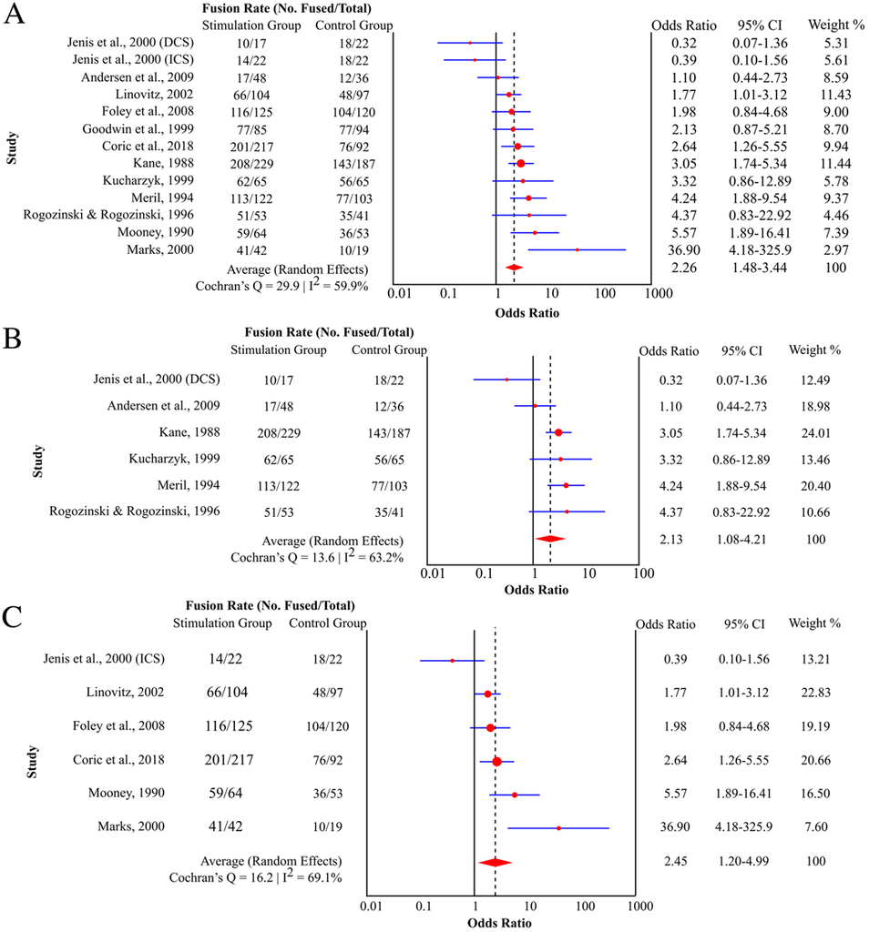

**FIG. 3.** Forest plots demonstrating random-effects meta-analysis of the fusion rates from all clinical studies (**A**), only clinical stud-

ies examining the effect of DCS on spinal fusion (**B**), and only clinical studies examining the effect of ICS on spinal fusion (**C**). Only

studies reporting fusion rates for intervention (i.e., electrical stimulation) and control groups are included. Figure is available in

color online only.

**J Neurosurg Spine** Volume 32 • January 2020

**119**

**Cottrill et al.**

terior lumbar interbody fusion, or posterolateral lumbar

fusion.<sup>47</sup> All patients were instructed to use the stimula-

tion device (precursor of the Biomet OrthoPak [Zimmer

Biomet]) for 24 hours/day for 9 months or until fusion

was confirmed radiologically. At the 12-month follow-

up visit, no significant difference in fusion rates was de-

tected between CCS-treated (90.6%) and control (81.9%)

patients (Table 4).

**Effect of ICS on Spinal Fusion**

Thirteen total studies—6 preclinical and 7 clinical—

describing the results of ICS met our inclusion criteria. Of

these, 3 preclinical and 6 clinical studies were included in

the meta-analysis.

Preclinical Data

Preclinical studies described the effects of ICS in dog

(n = 3), rabbit (n = 2), and rat (n = 1) models using poste-

rior facet fusion (n = 2) or posterolateral inter–transverse

process fusion (n = 4) of the lumbar spine. Four studies

involved one-level procedures, whereas 2 involved multi-

level fusions (≥ 2 levels). All studies used either autograft

(n = 5) or synthetic bone graft (n = 1); 2 studies used in-

strumentation (Table 2).

The fusion rate varied widely across studies, ranging

from 0% to 81% in treated groups and from 0% to 60% in

controls (Supplemental Fig. 2B). In the aggregate, the in-

cluded studies failed to show a significant difference in fu-

sion rates between ICS-treated animals and controls (OR

3.08 [95% CI 0.88–10.72], p > 0.05) (Table 4).

Clinical Data

All clinical studies investigating the effect of ICS on

spinal fusion examined adult patients (Table 3). Three

of the studies examined the effects in only patients with

difficult-to-fuse spines, defined by the studies as 1) pa-

tients with a herniated nucleus pulposus, degenerative

disc disease, spondylolisthesis, spinal stenosis, and/or

those who had undergone a prior failed fusion;<sup>14</sup> 2) those

who smoked and/or were undergoing multilevel fusion

with an allograft;<sup>34</sup> or 3) those who were age ≥ 65 years,

actively smoked, were undergoing multilevel fusion, had

undergone a prior failed fusion, had diabetes, and/or had

osteoporosis.<sup>26</sup> Two studies restricted patients to those

without a history of spine surgery, while the remaining

5 included both index and revision procedures. Three

studies involved only posterior/posterolateral fusion pro-

cedures, 3 involved only interbody procedures, and 1

involved either type of procedure. The spinal segments

investigated were cervical (n = 2) and lumbar/lumbosa-

cral (n = 5). Autograft alone was used in 1 study, allograft

alone in 1 study, and autograft and/or allograft in 5 stud-

ies. Instrumentation was used in all patients in 4 studies,

some patients in 2 studies, and none of the patients in 1

study.

Fusion rates varied between 63% and 98% in the ICS

group and between 49% and 87% in the control group

(Supplemental Fig. 3C). Patients receiving ICS were found

to have significant improvements in overall fusion rate rel-

ative to control patients (OR 2.45 [95% CI 1.20–4.99], p =

0.014) (Table 4 and Fig. 3C).

**Subanalysis of Clinical Data**

On meta-analysis, patients receiving some form of elec-

trical stimulation were found to have a 126% increase in

the odds of a successful fusion by last follow-up compared

to controls (Fig. 3A). Table 5 summarizes the subgroup

meta-analyses of the clinical data. The variables investi-

gated include those listed as characteristic of patients with

difficult-to-fuse spines, patients with a history of smoking,

those undergoing revision surgery, those in whom inter-

body fusion is performed, and those undergoing a multi-

level fusion, as well as the surgical level that was treated,

the type of graft material used, and whether instrumenta-

tion was placed.

Notably, one or more electrical stimulation therapies

resulted in statistically significant increases in the fusion

rates compared to no stimulation in the following sub-

groups: patients with difficult-to-fuse spines, smokers,

nonsmokers, patients undergoing index procedures, and

those undergoing interbody fusions, single-level fusions,

multilevel fusions, cervical fusions, lumbar/lumbosacral

fusions, fusions with allograft alone, fusions with instru-

mentation, and fusions without instrumentation. In con-

trast, significant differences could not be detected between

the fusion rates of patients receiving electrical stimulation

therapy and controls in the following subgroups: revision

surgery, posterior/posterolateral fusion subgroups, and au-

tograft alone (Table 5).

**Discussion**

Spinal fusion is performed in the treatment of spinal

pathologies of hundreds of thousands of Americans annu-

ally. Although most patients experience good outcomes,

many experience nonunion, which can be associated with

pain, persistent neurological compromise, and need for re-

vision surgery.<sup>24</sup> One class of surgical adjuvant therapies

designed to avoid this outcome is electrical stimulation, in-

cluding DCS, CCS, and ICS. In the current article, we have

reported on the results of a systematic review and meta-

analysis that evaluated the existing preclinical and clini-

cal literature with the goal of addressing two questions: 1)

To what degree does the technology improve bony fusion

in animal models? 2) To what degree does the technol-

ogy facilitate bony fusion in humans? We found that both

DCS and ICS lead to significant improvements in fusion

rates in humans and that DCS also produces significant in-

creases in fusion rates in preclinical studies. Considering

all electrical stimulation modalities as a whole, we found

that electrical stimulation can significantly increase fusion

rates among patients undergoing open fusion operations

for a range of spinal pathologies. Subanalyses suggested

that this effect persists in patients with difficult-to-fuse

spines, smokers, those undergoing index procedures, and

those undergoing interbody fusion. Further analyses inves-

tigating the effects based on the number of levels fused

and whether instrumentation was used suggested that

The merits of any technology can be winnowed down

to two questions: 1) Does it work? 2) Is it an economical

means of achieving the goal? For medical technologies,

**Cottrill et al.**

**J Neurosurg Spine** Volume 32 • January 2020

**120**

**TABLE 5. Random-effects subgroup meta-analysis of the clinical data***

Variable

Type of

EST

Authors & Year

Fusion Rate (no. fused/total)

Cochran’s

Q

OR (95% CI) &

p Value

Stimulation Group

Control Group

Studies limited to

difficult-to-fuse

spines†

DCS

Andersen et al., 2009

17/48

12/36

3.21

2.14 (0.94–4.86);

p > 0.05

Kucharzyk, 1999

62/65

56/65

Kane, 1988

25/31

15/28

Overall (95% CI)

73.3% (31.3–98.8%)

59.2% (24.9–89.0%)

ICS

Foley et al., 2008

116/125

104/120

0.25

**2.34 (1.33–4.10); p =**

**0.003**

Coric et al., 2018

201/217

76/92

Overall (95% CI)

**92.4% (89.4–95.0%)**

**84.6% (79.5–89.1%)**

All

Overall (95% CI)

**82.5% (64.1–95.2%)**

**70.8% (52.2–86.3%)**

3.59

**2.18 (1.43–3.32);**

**p < 0.001**

Smoker

DCS

Meril, 1994

85/92

42/59

4.44

2.46 (0.71–8.55);

p > 0.05

Rogozinski & Rogozinski, 1996

24/26

14/18

Jenis et al., 2000

5/10

8/13

Overall (95% CI)

83.1% (62.5–96.6%)

70.5% (60.9–79.3%)

ICS

Mooney, 1990

24/27

12/20

8.05

4.48 (0.45–44.26);

p > 0.05

Marks, 2000

18/19

0/3

Jenis et al., 2000

6/12

8/13

Overall (95% CI)

80.3% (55.2–96.6%)

47.0% (20.2–74.7%)

All

Overall (95% CI)

**82.2% (68.6–92.5%)**

**62.5% (49.3–74.8%)**

12.50

**2.84 (1.00–8.11);**

**p = 0.05**

Nonsmoker

DCS

Meril, 1994

26/28

14/20

1.45

3.79 (0.99–14.53);

p = 0.05

Rogozinski & Rogozinski, 1996

27/27

21/23

Jenis et al., 2000

6/7

8/9

Overall (95% CI)

94.1% (82.8–99.6%)

81.9% (67.1–93.0%)

ICS

Mooney, 1990

35/37

24/33

6.37

3.66 (0.34–39.8);

p > 0.05

Marks, 2000

23/23

10/16

Jenis et al., 2000

7/10

8/9

Overall (95% CI)

91.5% (74.4–99.6%)

71.7% (59.9–82.2%)

All

Overall (95% CI)

**93.1% (85.0–98.2%)**

**77.0% (67.3–85.4%)**

7.81

**3.58 (1.09–11.8);**

**p = 0.04**

Index surgery (no

prior back sur-

gery)

DCS

Meril, 1994

101/109

69/92

0.50

**3.69 (1.69–8.07); p =**

**0.001**

Rogozinski & Rogozinski, 1996

32/34

24/27

Overall (95% CI)

**92.4% (87.6–96.2%)**

**80.1% (66.1–91.1%)**

CCS

Goodwin et al., 1999

77/85

77/94

0

2.12 (0.87–5.21);

p > 0.05

Overall (95% CI)

90.6% (82.3–95.8%)

81.9% (72.6–89.1%)

ICS

Mooney, 1990

59/64

36/53

9.78

**5.52 (1.17–25.95);**

**p = 0.03**

Marks, 2000

38/38

6/14

Linovitz et al., 2002

66/104

48/97

Overall (95% CI)

**88.5% (60.6–100%)**

**55.0% (40.7–69.0%)**

All

Overall (95% CI)

**90.0% (78.9–97.3%)**

**69.2% (55.6–81.2%)**

11.14

**3.24 (1.69–6.21); p <**

**0.001**

Revision surgery

(prior back

surgery)

DCS

Meril, 1994

12/13

8/11

0.24

6.56 (0.98–44.0);

p = 0.05

Rogozinski & Rogozinski, 1996

19/19

11/14

Overall (95% CI)

95.7% (83.4–100)

74.2% (56.4–88.6%)

ICS

Marks, 2000

3/4

4/5

0

0.75 (0.03–17.51);

p > 0.05

Overall (95% CI)

75% (19.4–99.4)

80% (28.4–99.5%)

All

Overall (95% CI)

92.0% (75.2–99.7%)

74.4% (58.4–87.6%)

1.58

3.68 (0.72–18.73);

p > 0.05

CONTINUED ON PAGE 121 »

**J Neurosurg Spine** Volume 32 • January 2020

**121**

**Cottrill et al.**

**TABLE 5. Random-effects subgroup meta-analysis of the clinical data***

Variable

Type of

EST

Authors & Year

Fusion Rate (no. fused/total)

Cochran’s

Q

OR (95% CI) &

p Value

Stimulation Group

Control Group

Posterior or postero-

lateral fusion

DCS

Kane, 1988

208/229

143/187

11.34

1.77 (0.78–4.01);

p > 0.05

Kucharzyk, 1999

62/65

56/65

Andersen et al., 2009

17/48

12/36

Jenis et al., 2000

10/17

18/22

Rogozinski & Rogozinski, 1996

51/53

35/41

Overall (95% CI)

79.4% (56.7–95.1%)

73.6% (57.4–87.1%)

ICS

Jenis et al., 2000

14/22

18/22

3.94

0.95 (0.22–4.11);

p > 0.05

Linovitz et al., 2002

66/104

48/97

Overall (95% CI)

63.3% (54.8–71.4%)

64.7% (32.7–90.6%)

All

Overall (95% CI)

77.1% (56.3–92.6%)

74.7% (60.8–86.4%)

16.57

1.51 (0.82–2.79);

p > 0.05

Interbody fusion

DCS

Meril, 1994

113/122

77/103

0

**4.24 (1.88–9.54); p <**

**0.001**

Overall (95% CI)

92.6 (86.5–96.6%)

74.8% (65.2–82.8%)

ICS

Foley et al., 2008

116/125

104/120

5.68

**3.54 (1.71–7.31); p =**

**0.001**

Coric et al., 2018

201/217

76/92

Mooney, 1990

59/64

36/53

Marks, 2000

19/20

6/14

Overall (95% CI)

**92.3% (89.6–94.7%)**

**74.1% (59.9–86.2%)**

All

Overall (95% CI)

**92.3% (90.0–94.4%)**

**74.8% (64.4–84.0%)**

6.08

**3.56 (2.08–6.11); p <**

**0.001**

Single-level fusion

DCS

Kane, 1988

14/16

10/16

0.05

**4.96 (2.32–10.63);**

**p < 0.001**

Meril, 1994

85/93

49/73

Rogozinski & Rogozinski, 1996

16/16

18/20

Overall (95% CI)

**92.0% (84.6–97.2%)**

**72.7% (56.3–86.4%)**

ICS

Mooney, 1990

43/46

29/40

1.32

**8.77 (1.70–45.28);**

**p = 0.01**

Marks, 2000

18/18

6/12

Overall (95% CI)

**95.2% (87.0–99.5%)**

**64.1% (42.7–82.8%)**

All

Overall (95% CI)

**93.1% (88.5–96.6%)**

**69.6% (58.8–79.4%)**

1.68

**5.56 (2.91–10.64);**

**p < 0.001**

Multilevel (≥2) fusion

DCS

Kane, 1988

11/15

5/12

0.34

**3.40 (1.15–10.0);**

**p = 0.03**

Meril, 1994

23/24

26/28

Rogozinski & Rogozinski, 1996

35/37

17/21

Overall (95% CI)

**89.2% (76.1–97.5%)**

**74.6% (45.5–95.0%)**

ICS

Mooney, 1990

16/18

7/13

0.34

**9.46 (2.16–41.43);**

**p = 0.003**

Marks, 2000

23/24

4/7

Overall (95% CI)

**91.4% (81.4–97.8%)**

**54.6% (34.0–74.4%)**

All

Overall (95% CI)

**90.4% (83.4–95.6%)**

**68.0% (46.3–86.2%)**

1.88

**4.86 (2.03–11.62);**

**p < 0.001**

Cervical fusion

ICS

Foley et al., 2008

116/125

104/120

0.25

**2.34 (1.33–4.10); p =**

**0.003**

Coric et al., 2018

201/217

76/92

Overall (95% CI)

**92.4% (89.4–95.0%)**

**84.6% (79.5–89.1%)**

Lumbar or lumbosa-

cral fusion

DCS

Kane, 1988

208/229

143/187

13.60

**2.13 (1.08–4.21); p =**

**0.030**

Meril, 1994

113/122

77/103

Rogozinski & Rogozinski, 1996

51/53

35/41

Kucharzyk, 1999

62/65

56/65

Jenis et al., 2000

10/17

18/22

Andersen et al., 2009

17/48

12/36

Overall (95% CI)

**82.2% (65.8–94.1%)**

**73.9% (61.7–84.4%)**

» CONTINUED FROM PAGE 120

CONTINUED ON PAGE 122 »

**Cottrill et al.**

**J Neurosurg Spine** Volume 32 • January 2020

**122**

**TABLE 5. Random-effects subgroup meta-analysis of the clinical data***

Variable

Type of

EST

Authors & Year

Fusion Rate (no. fused/total)

Cochran’s

Q

OR (95% CI) &

p Value

Stimulation Group

Control Group

Lumbar or lumbo-

sacral fusion

(*cont’d*)

CCS

Goodwin et al., 1999

77/85

77/94

0

2.12 (0.87–5.21);

p > 0.05

Overall (95% CI)

90.6% (82.3–95.8%)

81.9% (72.6–89.1%)

ICS

Mooney, 1990

59/64

36/53

15.90

2.84 (0.76–10.72);

p > 0.05

Marks, 2000

41/42

10/19

Jenis et al., 2000

14/22

18/22

Linovitz et al., 2002

66/104

48/97

Overall (95% CI)

81.6% (59.9–96.0%)

62.2% (47.6–75.7%)

All

Overall (95% CI)

**82.9% (72.3–91.4%)**

**70.9% (61.6–79.4%)**

29.68

**2.25 (1.34–3.80); p =**

**0.002**

Autograft

DCS

Kane, 1988

208/229

143/187

8.86

2.03 (0.73–5.65);

p > 0.05

Meril, 1994

51/53

35/41

Kucharzyk, 1999

62/65

56/65

Jenis et al., 2000

10/17

18/22

Overall (95% CI)

89.4% (79.7–96.2%)

80.4% (75.1–85.2%)

ICS

Mooney, 1990

23/25

14/19

10.07

2.88 (0.28–29.58);

p > 0.05

Marks, 2000

19/20

5/11

Jenis et al., 2000

14/22

18/22

Overall (95% CI)

84.0% (63.6–97.0%)

68.9% (49.5–85.3%)

All

Overall (95% CI)

87.4% (78.9–93.9%)

78.5% (72.0–84.4%)

19.39

2.14 (0.85–5.37);

p > 0.05

Allograft

ICS

Mooney, 1990

25/27

16/22

2.28

**2.86 (1.18–6.95);**

**p = 0.02**

Marks, 2000

11/11

4/7

Foley et al., 2008

116/125

104/120

Overall (95% CI)

**92.8% (88.3–96.2%)**

**76.7% (59.2–90.4%)**

With instrumentation

DCS

Meril, 1994

24/24

51/63

9.15

2.25 (0.50–10.1);

p > 0.05

Rogozinski & Rogozinski, 1996

51/53

35/41

Kucharzyk, 1999

62/65

56/65

Jenis et al., 2000

10/17

18/22

Overall (95% CI)

91.4% (77.7–98.9%)

83.2% (77.6–88.1%)

ICS

Mooney, 1990

44/48

28/39

7.37

1.92 (0.94–3.93);

p > 0.05

Marks, 2000

9/10

1/1

Jenis et al., 2000

14/22

18/22

Foley et al., 2008

116/125

104/120

Coric et al., 2018

201/217

76/92

Overall (95% CI)

88.5% (81.4–94.1%)

82.4% (77.3–86.9%)

All

Overall (95% CI)

**89.8% (83.8–94.6%)**

**82.8% (79.3–86.1%)**

16.44

**1.94 (1.01–3.73);**

**p = 0.05**

Without instrumenta-

tion

DCS

Kane, 1988

208/229

143/187

5.92

**2.64 (1.20–5.81);**

**p = 0.02**

Meril, 1994

89/98

26/40

Andersen et al., 2009

17/48

12/36

Overall (95% CI)

**75.9% (45.3–96.3%)**

**59.3% (34.1–82.2%)**

ICS

Mooney, 1990

15/16

8/14

8.07

7.71 (0.86–69.38);

p > 0.05

Marks, 2000

32/32

9/18

Linovitz et al., 2002

66/104

48/97

Overall (95% CI)

88.2% (54.7–99.9%)

50.4% (41.9–58.9%)

All

Overall (95% CI)

**82.2% (63.7–95.0%)**

**56.0% (40.7–70.7%)**

14.03

**3.01 (1.56–5.84); p =**

**0.001**

» CONTINUED FROM PAGE 121

CONTINUED ON PAGE 123 »

**J Neurosurg Spine** Volume 32 • January 2020

**123**

**Cottrill et al.**

we also consider the safety of the technology. Our review

mainly addresses the first of these questions—namely,

whether electrical stimulation is an effective means of

promoting bony fusion. On the whole, our results suggest

that the answer to this question is yes, as the results of our

pooled analysis demonstrated significantly higher odds of

fusion in patients treated with electrical stimulation (OR

2.26, p < 0.001). However, more in-depth investigation

suggests that the majority of these results are driven by

DCS and ICS. Between these 2 technologies, though, there

appears to be no difference in efficacy.

This brings us to considering the questions of econom-

ics and safety profiles: 1) Are ICS and DCS economical

means of promoting bony fusion? 2) Are they safe? The

latter is most easily answered as both implantable DCS

and noninvasive ICS devices have been approved under

the relatively stringent FDA premarket approval process

(class III devices) based on results of randomized con-

trolled trials.<sup>5,34,47,53,57,72</sup> The former question, i.e., whether

the DCS and ICS devices are economical, is one that is

harder to answer.

At present there are no high-quality studies evaluating

the cost-effectiveness of electrical stimulation devices in

the spine literature. However, back-of-the-envelope calcu-

lations are possible using estimates of device cost, pseud-

arthrosis rates, and cost of revision surgery. Prior stud-

ies of pseudarthrosis have found that the direct surgical

costs of a revision operation are approximately $21,113 ±

$11,895 for cervical operations<sup>58</sup> and $28,069 ± $2508 for

lumbar operations.<sup>2</sup> To a gross approximation, this reduces

to $25,000 per reoperation. Based on the present results,

the approximate pseudarthrosis rate among patients re-

ceiving electrical stimulation therapy is 15%, compared

to 27% in the control population. Of these patients, ap-

proximately half may require surgical revision for pseudo-

arthrosis.<sup>24,45,61,62,80</sup> Accounting for this, the cost of surgical

revisions for pseudarthrosis averaged across patients re-

ceiving electrical stimulation therapy is $1875, compared

to $3375 for controls. For patients receiving electrical

stimulation therapy, though, the cost of the stimulation de-

vice is an estimated additional $4000–$5000. Therefore,

from a strictly financial standpoint, electrical stimulation

devices may be a cost-ineffective means of improving fu-

sion rates, except in patients with a high risk of nonunion.

The overall risk of pseudarthrosis among patients with

difficult-to-fuse spines—commonly defined as those in

whom prior fusion has failed, smokers, and those undergo-

ing multilevel fusion procedures—has been reported to ex-

suggesting that the use of electrical stimulation devices in

this patient population may be cost-effective. Consistent

with this, Medicare—the largest single insurer in the US—

covers these devices only for patients with a history of mul-

tilevel fusion or a history of one or more prior failed fusion

operations. This analysis does not consider the effect of

nonunion on indirect costs, namely, days of lost work and

decreased quality of life; however, it is likely that consider-

ation of indirect costs will only increase the cost-effective-

ness of these stimulation devices. Additional, high-quality

investigation is warranted to evaluate this point.

**Study Limitations**

There are several limitations to this study. First, we were

forced to exclude 6 preclinical and 3 clinical studies from

the meta-analysis as they lacked control groups for estima-

tion of odds ratios. This produces a potential selection bias

that may limit the generalizability of the data. Second, the

results of the study are based on a combination of pro-

spective and retrospective studies. Retrospective studies

are limited in the quality of the data they provide, which

consequently limits the generalizability of the results of

the present study. Nonetheless, we evaluated the quality

of the clinical studies included in the meta-analysis (us-

ing the Critical Appraisal Checklists) and deemed each to

have sufficient quality to be included in the present review.

Additionally, although we provide estimates of the over-

all effect of electrical stimulation therapies at large and in

subgroups, the heterogeneity of the included studies pre-

vents us from answering the following questions: 1) Which

patients will benefit most from electrical stimulation tech-

nologies? 2) For how long should treatment be continued?

Furthermore, the definition of fusion varied between stud-

ies, suggesting that the outcome may have been distinct

across studies, which would limit the validity of our meta-

analysis. We describe this heterogeneity by presenting the

definition and method of assessment of spinal fusion used

by each study. All clinical studies employed plain radio-

graph– or CT scan–based radiological assessment, both

of which are considered valid techniques in the clinical

literature. Although a CT scan provides higher-resolution

imaging and is therefore often considered the gold stan-

dard for fusion assessment, relative to standard radiogra-

phy it is more expensive, exposes the patient to high radia-

tion levels, and often provides no additional information.<sup>33</sup>

Nevertheless, the different assessment modalities impart

heterogeneity to the results, which we attempted to address

by employing random-effects versus fixed-effects models.

Lastly, we pooled the results of several different electrical

stimulation technologies. Though our results suggest that

**TABLE 5. Random-effects subgroup meta-analysis of the clinical data***

EST = electrical stimulation technology.

Boldface type indicates statistical significance.

* Only studies reporting the fusion rates for both the intervention (i.e., electrical stimulation) and control groups were included in the meta-analysis.

† These studies included only patients with known risk factors for pseudarthrosis: 1) age > 60 years;<sup>5</sup> 2) failed prior fusion, grade II or worse spondylolisthesis, multilevel

fusion, and/or other high-risk medical condition (e.g., gross obesity) (select cohort within study);<sup>57</sup> 3) multiple prior spine surgeries, failed prior fusion, segmental instabil-

ity, spinal stenosis, and/or spondylolisthesis;<sup>60</sup> 4) age ≥ 65 years, active smoker, multilevel fusion, prior failed fusion, diabetic, and/or osteoporotic;<sup>26</sup> or 5) active smokers

and/or multilevel fusion.<sup>34</sup>

» CONTINUED FROM PAGE 122

**Cottrill et al.**

**J Neurosurg Spine** Volume 32 • January 2020

**124**

ICS and DCS have similar effects, they employ distinct

technologies and have widely different patient compliance

levels given that the latter is an implanted device, whereas

the former is a wearable device. It is therefore possible that

limitations in patient compliance among the ICS group

limited the ability of our analysis to see differences in ef-

ficacy between the technologies. Given these limitations,

it is apparent that future studies are necessary to direct-

ly compare the effectiveness of these different electrical

stimulation technology modalities.

**Conclusions**

Here we report the results of the first systematic review

and meta-analysis analyzing the effectiveness of electri-

cal stimulation devices on spinal fusion in the preclinical

and clinical literature. We found that these devices lead to

significant increases in fusion rates, with a nearly fivefold

increase in the odds in preclinical studies and a more than

twofold increase in clinical studies. Subanalysis suggested

that among the clinical population, DCS and ICS lead

to significant decreases in pseudarthrosis rates, whereas

CCS does not. Additional research is needed to analyze

the cost-effectiveness of electrical stimulation devices to

identify those patients in whom these devices are likely

to be not only practically effective but also cost-effective.

**References**

1. Aaron RK, Ciombor DM, Keeping H, Wang S, Capuano A,

Polk C: Power frequency fields promote cell differentiation

coincident with an increase in transforming growth factor-

beta(1) expression. **Bioelectromagnetics 20:**453–458, 1999

2. Adogwa O, Owens R, Karikari I, Agarwal V, Gottfried ON,

Bagley CA, et al: Revision lumbar surgery in elderly patients

with symptomatic pseudarthrosis, adjacent-segment disease,

or same-level recurrent stenosis. Part 2. A cost-effectiveness

analysis: clinical article. **J Neurosurg Spine 18:**147–153,

2013

3. Adogwa O, Parker SL, Shau D, Mendelhall SK, Cheng J,

Aaronson O, et al: Long-term outcomes of revision fusion for

lumbar pseudarthrosis: clinical article. **J Neurosurg Spine**

**15:**393–398, 2011

4. Aleem IS, Aleem I, Evaniew N, Busse JW, Yaszemski M,

Agarwal A, et al: Efficacy of electrical stimulators for bone

healing: a meta-analysis of randomized sham-controlled tri-

als. **Sci Rep 6:**31724, 2016

5. Andersen T, Christensen FB, Egund N, Ernst C, Fruensgaard

S, Østergaard J, et al: The effect of electrical stimulation on

lumbar spinal fusion in older patients: a randomized, con-

trolled, multi-center trial: part 2: fusion rates. **Spine (Phila**

**Pa 1976) 34:**2248–2253, 2009

6. Balint R, Cassidy NJ, Cartmell SH: Electrical stimulation:

a novel tool for tissue engineering. **Tissue Eng Part B Rev**

**19:**48–57, 2013

7. Baranowski TJ, Black J: The mechanism of faradic stimula-

tion of osteogenesis, in Blank M, Findl E (eds): **Mechanistic**

**Approaches to Interactions of Electric and Electromag-**

**netic Fields with Living Systems.** Boston: Springer, 1987,

pp 399–416

8. Blackwell KA, Raisz LG, Pilbeam CC: Prostaglandins

in bone: bad cop, good cop? **Trends Endocrinol Metab**

**21:**294–301, 2010

9. Blumenthal SL, Baker J, Dossett A, Selby DK: The role of

anterior lumbar fusion for internal disc disruption. **Spine**

**(Phila Pa 1976) 13:**566–569, 1988

10. Bodamyali T, Bhatt B, Hughes FJ, Winrow VR, Kanczler JM,

Simon B, et al: Pulsed electromagnetic fields simultaneously

induce osteogenesis and upregulate transcription of bone

morphogenetic proteins 2 and 4 in rat osteoblasts in vitro.

**Biochem Biophys Res Commun 250:**458–461, 1998

11. Bodamyali T, Kanczler JM, Simon B, Blake DR, Stevens

CR: Effect of faradic products on direct current-stimulated

calvarial organ culture calcium levels. **Biochem Biophys Res**

**Commun 264:**657–661, 1999

12. Boden SD, Sumner DR: Biologic factors affecting spinal fu-

sion and bone regeneration. **Spine (Phila Pa 1976) 20 (24**

**Suppl):**102S–112S, 1995

13. Bolesta MJ, Rechtine GR II, Chrin AM: Three- and four-level

anterior cervical discectomy and fusion with plate fixation: a

prospective study. **Spine (Phila Pa 1976) 25:**2040–2046, 2000

14. Bose B: Outcomes after posterolateral lumbar fusion with

instrumentation in patients treated with adjunctive pulsed

electromagnetic field stimulation. **Adv Ther 18:**12–20, 2001

15. Bozic KJ, Glazer PA, Zurakowski D, Simon BJ, Lipson SJ,

Hayes WC: In vivo evaluation of coralline hydroxyapatite and

direct current electrical stimulation in lumbar spinal fusion.

**Spine (Phila Pa 1976) 24:**2127–2133, 1999

16. Brighton CT, Adler S, Black J, Itada N, Friedenberg ZB:

Cathodic oxygen consumption and electrically induced osteo-

genesis. **Clin Orthop Relat Res (107):**277–282, 1975

17. Brighton CT, Wang W, Seldes R, Zhang G, Pollack SR: Sig-

nal transduction in electrically stimulated bone cells. **J Bone**

**Joint Surg Am 83:**1514–1523, 2001

18. Brown CW, Orme TJ, Richardson HD: The rate of pseudar-

throsis (surgical nonunion) in patients who are smokers and

patients who are nonsmokers: a comparison study. **Spine**

**(Phila Pa 1976) 11:**942–943, 1986

19. Cain CD, Adey WR, Luben RA: Evidence that pulsed elec-

tromagnetic fields inhibit coupling of adenylate cyclase

by parathyroid hormone in bone cells. **J Bone Miner Res**

**2:**437–441, 1987

20. Calandruccio RA, Benton BF: Anterior lumbar fusion. **Clin**

**Orthop Relat Res 35:**63–68, 1964

21. Cho M, Hunt TK, Hussain MZ: Hydrogen peroxide stimu-

lates macrophage vascular endothelial growth factor release.

**Am J Physiol Heart Circ Physiol 280:**H2357–H2363, 2001

22. Cho PG, Ji GY, Ha Y, Lee HY, Shin DA: Effect of the type of

electrical stimulation on spinal fusion in a rat posterolateral

spinal fusion model. **Spine J 19:**1106–1120, 2019

23. Choi YH, Choi JH, Oh JW, Lee KY: Calmodulin-dependent

kinase II regulates osteoblast differentiation through regula-

tion of Osterix. **Biochem Biophys Res Commun 432:**248–

255, 2013

24. Chun DS, Baker KC, Hsu WK: Lumbar pseudarthrosis: a

review of current diagnosis and treatment. **Neurosurg Focus**

**39(4):**E10, 2015

25. Cook SD, Patron LP, Christakis PM, Bailey KJ, Banta C,

Glazer PA: Direct current stimulation of titanium interbody

fusion devices in primates. **Spine J 4:**300–311, 2004

26. Coric D, Bullard DE, Patel VV, Ryaby JT, Atkinson BL, He

D, et al: Pulsed electromagnetic field stimulation may im-

prove fusion rates in cervical arthrodesis in high-risk popula-

tions. **Bone Joint Res 7:**124–130, 2018

27. Cottrill E, Ahmed AK, Lessing N, Pennington Z, Ishida W,

Perdomo-Pantoja A, et al: Investigational growth factors

utilized in animal models of spinal fusion: systematic review.

**World J Orthop 10:**176–191, 2019

28. Dejardin LM, Kahanovitz N, Arnoczky SP, Simon BJ: The

effect of varied electrical current densities on lumbar spinal

fusions in dogs. **Spine J 1:**341–347, 2001

29. Epstein N, Epstein JA, Benjamin V, Ransohoff J: Traumatic

myelopathy in patients with cervical spinal stenosis without

fracture or dislocation: methods of diagnosis, management,

and prognosis. **Spine (Phila Pa 1976) 5:**489–496, 1980

**J Neurosurg Spine** Volume 32 • January 2020

**125**

**Cottrill et al.**

30. Feyen JHM, Di Bon A, van der Plas A, Löwik CWGM,

Nijweide PJ: Effects of exogenous prostanoids on the pro-

liferation of osteoblast-like cells in vitro. **Prostaglandins**

**30:**827–840, 1985

31. Fischer CR, Cassilly R, Cantor W, Edusei E, Hammouri Q,

Errico T: A systematic review of comparative studies on bone

graft alternatives for common spine fusion procedures. **Eur**

**Spine J 22:**1423–1435, 2013

32. Flynn JC, Hoque MA: Anterior fusion of the lumbar spine.

End-result study with long-term follow-up. **J Bone Joint**

**Surg Am 61:**1143–1150, 1979

33. Fogel GR, Toohey JS, Neidre A, Brantigan JW: Fusion as-

sessment of posterior lumbar interbody fusion using radio-

lucent cages: x-ray films and helical computed tomography

scans compared with surgical exploration of fusion. **Spine J**

**8:**570–577, 2008

34. Foley KT, Mroz TE, Arnold PM, Chandler HC Jr, Dixon RA,

Girasole GJ, et al: Randomized, prospective, and controlled

clinical trial of pulsed electromagnetic field stimulation for

cervical fusion. **Spine J 8:**436–442, 2008

35. France JC, Norman TL, Buchanan MM, Scheel M, Veale M,

Ackerman ES, et al: Direct current stimulation for spine fu-

sion in a nicotine exposure model. **Spine J 6:**7–13, 2006

36. France JC, Norman TL, Santrock RD, McGrath B, Simon BJ:

The efficacy of direct current stimulation for lumbar inter-

transverse process fusions in an animal model. **Spine (Phila**

**Pa 1976) 26:**1002–1008, 2001

37. Fredericks DC, Smucker J, Petersen EB, Bobst JA, Gan JC,

Simon BJ, et al: Effects of direct current electrical stimu-

lation on gene expression of osteopromotive factors in a

posterolateral spinal fusion model. **Spine (Phila Pa 1976)**

**32:**174–181, 2007

38. Freeman MF, Tukey JW: Transformations related to the an-

gular and the square root. **Ann Math Stat** **21:**607–611, 1950

39. Friedenberg ZB, Andrews ET, Smolenski BI, Pearl BW,

Brighton CT: Bone reaction to varying amounts of direct cur-

rent. **Surg Gynecol Obstet 131:**894–899, 1970

40. Friedenberg ZB, Brighton CT: Bioelectric potentials in bone.

**J Bone Joint Surg Am 48:**915–923, 1966

41. Friedenberg ZB, Harlow MC, Heppenstall RB, Brighton CT:

The cellular origin of bioelectric potentials in bone. **Calcif**

**Tissue Res 13:**53–62, 1973

42. Friedenberg ZB, Zemsky LM, Pollis RP, Brighton CT: The

response of non-traumatized bone to direct current. **J Bone**

**Joint Surg Am 56:**1023–1030, 1974

43. Fu R, Selph S, McDonagh M, Peterson K, Tiwari A, Chou R,

et al: Effectiveness and harms of recombinant human bone

morphogenetic protein-2 in spine fusion: a systematic review

and meta-analysis. **Ann Intern Med 158:**890–902, 2013

44. Fukada E, Yasuda I: On the piezoelectric effect of bone. **J**

**Phys Soc Jpn** **12:**1158–1162, 1957

45. Girardo M, Bettini N, Dema E, Cervellati S: Uninstrumented

posterolateral spinal arthrodesis: is it the gold standard tech-

nique for I degrees and II degrees grade spondylolisthesis in

adolescence? **Eur Spine J 18 (Suppl 1):**126–132, 2009

46. Glazer PA, Heilmann MR, Lotz JC, Bradford DS: Use of

electromagnetic fields in a spinal fusion. A rabbit model.

**Spine (Phila Pa 1976) 22:**2351–2356, 1997

47. Goodwin CB, Brighton CT, Guyer RD, Johnson JR, Light

KI, Yuan HA: A double-blind study of capacitively coupled

electrical stimulation as an adjunct to lumbar spinal fusions.

**Spine (Phila Pa 1976) 24:**1349–1357, 1999

48. Guizzardi S, Di Silvestre M, Govoni P, Scandroglio R:

Pulsed electromagnetic field stimulation on posterior spinal

fusions: a histological study in rats. **J Spinal Disord 7:**36–

40, 1994

49. Haglin JM, Jain S, Eltorai AEM, Daniels AH: Bone growth

stimulation: a critical analysis review. **JBJS Rev 5:**e8, 2017

50. Hartshorne E: On the causes and treatment of pseudarthrosis,

and especially of that form of it sometimes called supernu-

merary joint. **Am J Med** **1:**143, 1841

51. Hofler RC, Swong K, Martin B, Wemhoff M, Jones GA:

Risk of pseudoarthrosis after spinal fusion: analysis from the

Healthcare Cost and Utilization Project. **World Neurosurg**

**120:**e194–e202, 2018

52. Ito M, Fay LA, Ito Y, Yuan MR, Edwards WT, Yuan HA:

The effect of pulsed electromagnetic fields on instrumented

posterolateral spinal fusion and device-related stress shield-

ing. **Spine (Phila Pa 1976) 22:**382–388, 1997

53. Jenis LG, An HS, Stein R, Young B: Prospective compari-

son of the effect of direct current electrical stimulation and

pulsed electromagnetic fields on instrumented posterolateral

lumbar arthrodesis. **J Spinal Disord 13:**290–296, 2000

54. Kahanovitz N, Arnoczky SP: The efficacy of direct current

electrical stimulation to enhance canine spinal fusions. **Clin**

**Orthop Relat Res (251):**295–299, 1990

55. Kahanovitz N, Arnoczky SP, Hulse D, Shires PK: The effect

of postoperative electromagnetic pulsing on canine posterior

spinal fusions. **Spine (Phila Pa 1976) 9:**273–279, 1984

56. Kahanovitz N, Arnoczky SP, Nemzek J, Shores A: The effect

of electromagnetic pulsing on posterior lumbar spinal fusions

in dogs. **Spine (Phila Pa 1976) 19:**705–709, 1994

57. Kane WJ: Direct current electrical bone growth stimulation

for spinal fusion. **Spine (Phila Pa 1976) 13:**363–365, 1988

58. Kim EJ, Chotai S, Wick JB, Stonko DP, Sivaganesan A,

Devin CJ: Patient-reported outcomes and costs associated

with revision surgery for degenerative cervical spine dis-

eases. **Spine (Phila Pa 1976) 43:**E423–E429, 2018

59. Kornblum MB, Fischgrund JS, Herkowitz HN, Abraham DA,

Berkower DL, Ditkoff JS: Degenerative lumbar spondylo-

listhesis with spinal stenosis: a prospective long-term study

comparing fusion and pseudarthrosis. **Spine (Phila Pa 1976)**

**29:**726–734, 2004

60. Kucharzyk DW: A controlled prospective outcome study of

implantable electrical stimulation with spinal instrumenta-

tion in a high-risk spinal fusion population. **Spine (Phila Pa**

**1976) 24:**465–469, 1999

61. Lamberg TS, Remes VM, Helenius IJ, Schlenzka DK, Yr-

jönen TA, Osterman KE, et al: Long-term clinical, functional

and radiological outcome 21 years after posterior or postero-

lateral fusion in childhood and adolescence isthmic spondy-

lolisthesis. **Eur Spine J 14:**639–644, 2005

62. Leven D, Cho SK: Pseudarthrosis of the cervical spine: risk

factors, diagnosis and management. **Asian Spine J 10:**776–

786, 2016

63. Linovitz RJ, Pathria M, Bernhardt M, Green D, Law MD,

McGuire RA, et al: Combined magnetic fields accelerate and

increase spine fusion: a double-blind, randomized, placebo

controlled study. **Spine (Phila Pa 1976) 27:**1383–1389, 2002

64. Loguidice VA, Johnson RG, Guyer RD, Stith WJ, Ohnmeiss

DD, Hochschuler SH, et al: Anterior lumbar interbody fusion.

**Spine (Phila Pa 1976) 13:**366–369, 1988

65. Lopez AJ, Scheer JK, Dahdaleh NS, Patel AA, Smith ZA:

Lumbar spinous process fixation and fusion: a systematic

review and critical analysis of an emerging spinal technology.

**Clin Spine Surg 30:**E1279–E1288, 2017

66. Luben RA, Cain CD, Chen MCY, Rosen DM, Adey WR:

Effects of electromagnetic stimuli on bone and bone cells

in vitro: inhibition of responses to parathyroid hormone by

low-energy low-frequency fields. **Proc Natl Acad Sci U S A**

**79:**4180–4184, 1982

67. MacEwan MR, Talcott MR, Moran DW, Leuthardt EC: Novel

spinal instrumentation to enhance osteogenesis and fusion: a

preliminary study. **J Neurosurg Spine 25:**318–327, 2016

68. Marks RA: Spine fusion for discogenic low back pain: out-

comes in patients treated with or without pulsed electromag-

netic field stimulation. **Adv Ther 17:**57–67, 2000

69. Meril AJ: Direct current stimulation of allograft in anterior

**Cottrill et al.**

**J Neurosurg Spine** Volume 32 • January 2020

**126**

and posterior lumbar interbody fusions. **Spine (Phila Pa**

**1976) 19:**2393–2398, 1994

70. Moher D, Cook DJ, Eastwood S, Olkin I, Rennie D, Stroup

DF: Improving the quality of reports of meta-analyses of ran-

domised controlled trials: the QUOROM statement. Quality

of Reporting of Meta-analyses. **Lancet 354:**1896–1900, 1999

71. Moola S, Munn Z, Tufanaru C, Aromataris E, Sears K,

Sfetcu R, et al: Chapter 7: Systematic reviews of etiology

and risk, in Aromataris E, Munn Z (eds): **Joanna Briggs**

**Institute Reviewer’s Manual.** Adelaide: The Joanna Briggs

Institute, 2017 (https://reviewersmanual.joannabriggs.org/)

[Accessed June 18, 2019]

72. Mooney V: A randomized double-blind prospective study of

the efficacy of pulsed electromagnetic fields for interbody

lumbar fusions. **Spine (Phila Pa 1976) 15:**708–712, 1990

73. Morris MT, Tarpada SP, Cho W: Bone graft materials for

posterolateral fusion made simple: a systematic review. **Eur**

**Spine J 27:**1856–1867, 2018

74. Nerubay J, Katznelson A: Clinical evaluation of an electrical

current stimulator in spinal fusions. **Int Orthop 7:**239–242,

1984

75. Nerubay J, Marganit B, Bubis JJ, Tadmor A, Katznelson A:

Stimulation of bone formation by electrical current on spinal

fusion. **Spine (Phila Pa 1976) 11:**167–169, 1986

76. Poorman GW, Jalai CM, Boniello AJ, Worley N, McClelland

S III, Passias PG: Bone morphogenetic protein in adult spinal

deformity surgery: a meta-analysis. **Eur Spine J** **26:**2094–

2102, 2017

77. Rajaee SS, Bae HW, Kanim LE, Delamarter RB: Spinal fu-

sion in the United States: analysis of trends from 1998 to

2008. **Spine (Phila Pa 1976) 37:**67–76, 2012

78. Rogozinski A, Rogozinski C: Efficacy of implanted bone

growth stimulation in instrumented lumbosacral spinal fu-

sion. **Spine (Phila Pa 1976) 21:**2479–2483, 1996

79. Salamanna F, Sartori M, Brodano GB, Griffoni C, Martini L,

Boriani S, et al: Mesenchymal stem cells for the treatment of

spinal arthrodesis: from preclinical research to clinical sce-

nario. **Stem Cells Int 2017:**3537094, 2017

80. Slizofski WJ, Collier BD, Flatley TJ, Carrera GF, Hellman

RS, Isitman AT: Painful pseudarthrosis following lumbar

spinal fusion: detection by combined SPECT and planar bone

scintigraphy. **Skeletal Radiol 16:**136–141, 1987

81. Smeeth L, Haines A, Ebrahim S: Numbers needed to treat

derived from meta-analyses—sometimes informative, usually

misleading. **BMJ 318:**1548–1551, 1999

82. Stauffer RN, Coventry MB: Anterior interbody lumbar spine

fusion. Analysis of Mayo Clinic series. **J Bone Joint Surg**

**Am 54:**756–768, 1972

83. Stippick TW, Sheller MR: Combined magnetic fields provide

robust coverage for interbody and posterolateral lumbar spi-

nal fusion sites. **Med Biol Eng Comput 54:**113–122, 2016

84. Tejano NA, Puno R, Ignacio JMF: The use of implantable

direct current stimulation in multilevel spinal fusion without

instrumentation. A prospective clinical and radiographic

evaluation with long-term follow-up. **Spine (Phila Pa 1976)**

**21:**1904–1908, 1996

85. Tepper OM, Callaghan MJ, Chang EI, Galiano RD, Bhatt

KA, Baharestani S, et al: Electromagnetic fields increase in

vitro and in vivo angiogenesis through endothelial release of

FGF-2. **FASEB J 18:**1231–1233, 2004

86. Toth JM, Seim HB III, Schwardt JD, Humphrey WB, Wall-

skog JA, Turner AS: Direct current electrical stimulation

increases the fusion rate of spinal fusion cages. **Spine (Phila**

**Pa 1976) 25:**2580–2587, 2000

87. Tsutsumimoto T, Shimogata M, Yoshimura Y, Misawa H:

Union versus nonunion after posterolateral lumbar fusion: a

comparison of long-term surgical outcomes in patients with

degenerative lumbar spondylolisthesis. **Eur Spine J 17:**1107–

1112, 2008

88. Wang Z, Clark CC, Brighton CT: Up-regulation of bone mor-

phogenetic proteins in cultured murine bone cells with use of

specific electric fields. **J Bone Joint Surg Am 88:**1053–1065,

2006

89. Weiss AJ, Elixhauser A, Andrews RM: Characteristics of

operating room procedures in U.S. hospitals, 2011: Statisti-

cal Brief #170, in **Healthcare Cost and Utilization Project**

**(HCUP) Statistical Briefs.** Rockville, MD: Agency for

Healthcare Research and Quality (US), 2014

90. Welch WC, Willis SL, Gerszten PC: Implantable direct cur-

rent stimulation in para-axial cervical arthrodesis. **Adv Ther**

**21:**389–400, 2004

91. Yoshihara H: Rods in spinal surgery: a review of the litera-

ture. **Spine J 13:**1350–1358, 2013

92. Zayzafoon M: Calcium/calmodulin signaling controls osteo-

blast growth and differentiation. **J Cell Biochem 97:**56–70,

2006

93. Zhuang H, Wang W, Seldes RM, Tahernia AD, Fan H, Brigh-

ton CT: Electrical stimulation induces the level of TGF-beta1

mRNA in osteoblastic cells by a mechanism involving cal-

cium/calmodulin pathway. **Biochem Biophys Res Commun**

**237:**225–229, 1997

94. Zhuo X, Li C, Li B, Li Z, Lv H, Huang J, et al: Effects of

combined magnetic fields treatment and nano-hydroxyapatite

coating on porous biphasic calcium phosphate bone graft in

rabbit spinal fusion model. **Spine (Phila Pa 1976) 43:**E625–

E633, 2018

**Disclosures**

Dr. Goodwin reports being a consultant for Augmedics and

ROM3, having an ownership stake in AOSpine/NREF, and receiv-

ing textbook royalties from Kendall Hunt. Dr. Theodore receives

royalties from DePuy and Globus Medical Inc.; he is a consultant

for Globus. Dr. Witham reports receiving non–study-related grant

support from the Gordon and Marilyn Macklin Foundation and

Eli Lilly and Company; he is a consultant for DePuy Synthes

Spine. Dr. Sciubba is a consultant for Baxter, DePuy Synthes, Glo-

bus, K2M, Medtronic, NuVasive, and Stryker. Mr. Cottrill reports

receiving non–study-related grant support from the National Insti-

tute on Aging (F30AG063445).

**Author Contributions**

Conception and design: Sciubba, Cottrill, Pennington. Acquisition

of data: Cottrill, Pennington. Analysis and interpretation of data:

all authors. Drafting the article: all authors. Critically revising the

article: all authors. Reviewed submitted version of manuscript: all

authors. Approved the final version of the manuscript on behalf

of all authors: Sciubba. Statistical analysis: Cottrill, Pennington,

Ahmed. Administrative/technical/material support: Sciubba, The-

odore, Witham. Study supervision: Sciubba, Theodore, Witham.

**Supplemental Information**

Online-Only Content

Supplemental material is available with the online version of the

article.

*Critical Appraisal Checklists* and *Supplemental Tables and*

*Figures.* https://thejns.org/doi/suppl/10.3171/2019.5.SPINE19465.

**Correspondence**

Daniel Sciubba: Johns Hopkins School of Medicine, Baltimore,

MD. dsciubb1@jhmi.edu.